# PhD Chapter 3 - RelativeSize

Emanuele Giacomuzzo

2024-10-21 11:15

## Design

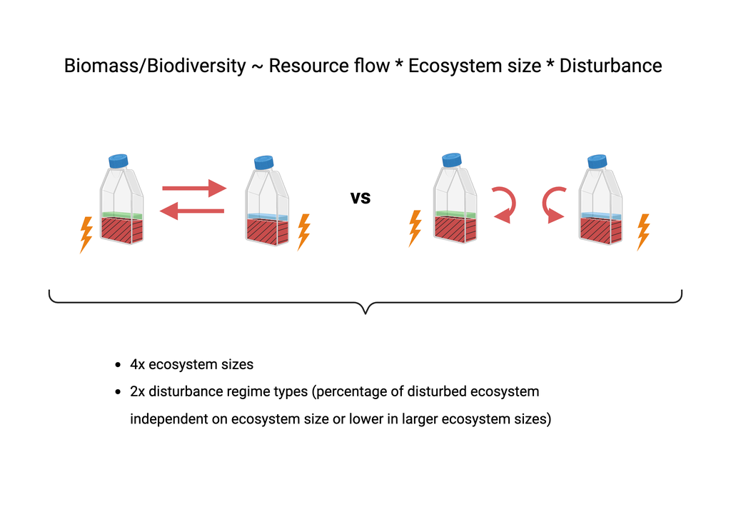

## Parameters

```r
# --- SET PARAMETERS FOR R MARKDOWN AND THE GENERAL RUNNING OF THE CODE --- #

knitr::opts_chunk$set(message = FALSE,
                      cache = FALSE,
                      autodep = FALSE)
start_time = Sys.time()
recompute_analyses = FALSE
```

```r
# --- SET PARAMETERS NECESSARY TO USE THE PACKAGE BEMOVI (INCLUDES SAMPLING PARAMETERS) --- #

# Define time points and associated sampling days

time_points = 0:7
sampling_days = c(0, 4, 8, 12, 16, 20, 24, 28)

# Define parameters used for analysing the videos in the package BEMOVI

fps = 25  # Frames per second (frame rate of the video)
seconds_per_video = 5  # Duration of each video in seconds
total_frames = fps * seconds_per_video  # Total number of frames in each video
measured_volume = 34.4  # Volume measured for each video in microliters (µL)
volume_recorded_μl = measured_volume  # Storing the measured volume in µL
volume_recorded_ml = volume_recorded_μl * 10**-3  # Converting the volume from µL to milliliters (mL)
pixel_to_scale = 4.05  # Conversion factor for pixels to µm
filter_min_net_disp = 25  # Minimum net displacement for an object to be considered a protist (pixels)
filter_min_duration = 1  # Minimum duration an object must be tracked to be considered a protist (seconds)
filter_detection_freq = 0.1  # Minimum frequency of detection in the video for an object to be considered a protist (detected frames / total frames)
filter_median_step_length = 3  # Minimum step length for an object to be considered a protist (pixels)
threshold_levels = c(13, 40) # Two lower pixel intensity thresholds for ImageJ to distinguish background from protists (higher threshold used for Ble)
video.description.folder = "0_video_description/" # Folder where the video descriptions (metadata about each video) are stored
video.description.file = "video_description.txt" # Filename of the text file containing the description of each video
merged_data_folder = "5_merged_data/" # Folder where the merged data files from the analysis will be stored

# Define columns that will be used for identifying species based on their movement and morphological characteristics

columns_for_species_ID = c(
  "mean_grey",         # Mean grayscale value (intensity) of the detected protist (brightness)
  "sd_grey",           # Standard deviation of the grayscale values (intensity variation)
  "mean_area",         # Mean area (in pixels) of the detected protist
  "sd_area",           # Standard deviation of the protist's area
  "mean_perimeter",    # Mean perimeter (length around the protist) of the detected protist
  "mean_turning",      # Mean turning angle of the protist's trajectory (how much the protist changes direction)
  "sd_turning",        # Standard deviation of the turning angles (variability in direction change)
  "sd_perimeter",      # Standard deviation of the protist's perimeter
  "mean_major",        # Mean length of the major axis of the protist (longest dimension)
  "sd_major",          # Standard deviation of the major axis length
  "mean_minor",        # Mean length of the minor axis of the protist (shortest dimension)
  "sd_minor",          # Standard deviation of the minor axis length
  "mean_ar",           # Mean aspect ratio (ratio of major to minor axis length)
  "sd_ar",             # Standard deviation of the aspect ratio
  "duration",          # Duration of time the protist is tracked in the video
  "max_net",           # Maximum net displacement (greatest straight-line distance traveled)
  "net_disp",          # Total net displacement (total straight-line distance from start to end of the trajectory)
  "net_speed",         # Mean net speed (speed based on net displacement)
  "gross_disp",        # Total gross displacement (total distance traveled including all movement)
  "max_step",          # Maximum step length (largest distance moved between two consecutive frames)
  "min_step",          # Minimum step length (smallest distance moved between two consecutive frames)
  "sd_step",           # Standard deviation of the step lengths (variability in frame-to-frame movement)
  "sd_gross_speed",    # Standard deviation of gross speed (variability in speed over time)
  "max_gross_speed",   # Maximum gross speed (highest speed achieved)
  "min_gross_speed")    # Minimum gross speed (lowest speed detected)
```

```r
# --- SET PARAMETERS RELATED TO RESOURCE FLOWS --- #

resource_flow_days = c(5, 9, 13, 17, 21, 25)
fixed_label = "Disturbance percentage FIXED"
relative_label = "Disturbance percentage DECREASING WITH SIZE"
```

```r
# --- SET PARAMETERS RELATED TO PROTISTS --- #

protist_species = c("Ble",
                    "Cep",
                    "Col",
                    "Eug",
                    "Eup",
                    "Lox",
                    "Pau",
                    "Pca",
                    "Spi",
                    "Spi_te",
                    "Tet")
protist_sepcies_ordered_by_size = c("Tet",
                                     "Col",
                                     "Eup",
                                     "Pau",
                                     "Cep",
                                     "Lox",
                                     "Pca",
                                     "Spi_te",
                                     "Ble",
                                     "Spi")
protist_species_indiv_per_ml = paste0(protist_species, "_indiv_per_ml")
protist_species_bioarea_mm2_per_ml = paste0(protist_species, "_bioarea_mm2_per_ml")
protist_species_dominance = paste0(protist_species_bioarea_mm2_per_ml, "_dominance")
```

```r
# --- SET PARAMETERS RELATED TO INDIVIDUALS --- #

# Initialise the dataset "ds_individuals" and "training_individuals"

ds_individuals = list()
training_individuals = list()
```

```r
# --- SET PARAMETERS RELATED TO ECOSYSTEMS --- #

# Initialise the dataset "ds_ecosystems_effect_size"

ds_ecosystems_effect_size = list()

# Define ecosystems to take off because of problems in the experiment

ecosystems_to_take_off = NA

# Define the variables you want to calculate for each ecosystem

variables_ecosystems = c("bioarea_mm2_per_ml",
                        "indiv_per_ml",
                        "species_richness",
                        "shannon",
                        "evenness_pielou",
                        protist_species_indiv_per_ml,
                        protist_species_dominance)

# Define the levels of variables

connection_ordered = c("unconnected", "connected")
ecosystem_sizes_ml = c(6.43, 9.00, 15.00, 45.00)

# Import the information about ecosystems

ecosystem_info = read.csv(here("1_data", "ecosystem_info.csv"), header = TRUE) %>%
  rename(ecosystem_ID = culture_ID,
         ecosystem_type = eco_metaeco_type,
         ecosystem_size_ml = patch_size_ml) %>%
  mutate(connection = factor(x = ifelse(metaecosystem == "yes",
                                        "connected",
                                        "unconnected"),
                             levels = connection_ordered),
         disturbance_percentage = factor(x = ifelse(flow == "absolute",
                                                    "decreasing_with_size",
                                                    "fixed"))) %>%
  select(ecosystem_ID,
         system_nr,
         ecosystem_size_ml,
         trophic_type,
         connection,
         disturbance_percentage)

# Find the number of ecosystems in the experiment

n_ecosystems = max(ecosystem_info$ecosystem_ID)
```

```r
# --- SET PARAMETERS RELATED TO META-ECOSYSTEMS --- #

# Initialise the "ds_metaecosystems" dataset
ds_metaecosystems = list()

# Define meta-ecosystems to take off because of problems in the experiment

metaecosystems_to_take_off = NA

# Define the variables you want to calculate for each meta-ecosystem

variables_metaecos = c("total_metaecosystem_bioarea_mm2")

# Find the number of meta-ecosystems in the experiment

system_nr_metaecosystems = ecosystem_info %>%
  filter(connection == "connected") %>%
  pull(system_nr) %>%
  unique

n_metaecosystems = length(system_nr_metaecosystems)

# Select which unconnected meta-ecosystems should be linked to form unconnected meta-ecosystems

unconnected_metaecosystems_selected = c("1|7",
                                        "2|8",
                                        "3|9",
                                        "4|10",
                                        "5|11",
                                        "6|12",

                                        "13|19",
                                        "14|20",
                                        "15|21",
                                        "16|22",
                                        "17|23",
                                        "18|24",

                                        "25|31",
                                        "26|32",
                                        "27|33",
                                        "28|34",
                                        "29|35",
                                        "30|36",

                                        "37|43",
                                        "38|44",
                                        "39|45",
                                        "40|46",
                                        "41|47",
                                        "42|48",

                                        "97|103",
                                        "98|104",
                                        "99|105",
                                        "100|106",
                                        "101|107",
                                        "102|108",

                                        "109|115",
                                        "110|116",
                                        "111|117",
                                        "112|118",
                                        "113|119",
                                        "114|120",

                                        "121|127",
                                        "122|128",
                                        "123|129",
                                        "124|130",
                                        "125|131",
                                        "126|132",

                                        "133|139",
                                        "134|140",
                                        "135|141",
                                        "136|142",
                                        "137|143",
                                        "138|144")
```

```r
# --- SET PARAMETERS FOR PLOTTING --- #

# Set line colours

treatment_colours_metaecosystems = c("6.43 ml" = "#ffeda0",
                                     "9.00 ml" = "#fecc5c",
                                     "15.00 ml" = "#fd8d3c",
                                     "45.00 ml" = "#e31a1c")

treatment_colours_autotrophic = c("6.43 ml" = "#e5f5e0",
                                  "9.00 ml" = "#b2e2e2",
                                  "15.00 ml" = "#66c2a4",
                                  "45.00 ml" = "#238b45")

treatment_colours_heterotrophic = c("6.43 ml" = "#deebf7",
                                    "9.00 ml" = "#bdd7e7",
                                    "15.00 ml" = "#6baed6",
                                    "45.00 ml" = "#2171b5")

light_colour_metaecos = "#fecc5c"
dark_colour_metaecos = "#e31a1c"
light_colour_auto = "#66c2a4"
dark_colour_auto = "#00441b"
light_colour_hetero = "#08306b"
dark_colour_hetero = "#9ecae1"

# Set line types

treatment_linetypes = c("connected" = "solid",
                        "unconnected" = "longdash")

# Set line labels

disturbance_labels = c("fixed" = "no interaction",
                       "decreasing_with_size" = "interaction size * disturbance")

# Set figure height and width in the RMD output

figures_width_rmd_output = 10
figures_height_rmd_output = 8

# Set parameters legend

legend_position = "top"
legend_width_cm = 2
size_legend = 12

# Set parameters axes

size_x_axis = 16
size_y_axis = 14

# Set parameters boxplots

boxplot_width = 2

# Set parameters points & error bars

treatment_points_size = 2.5
treatment_points_size_small = 1.5
width_errorbar = 2
dodging_error_bar = 0.5
dodging = 0.5

# Set parameters lines

treatment_lines_linewidth = 1

# Set parameters resource flow line (vertical line indicating the days of the resource flow)

resource_flow_line_type = "solid"
resource_flow_line_colour = "#d9d9d9"
resource_flow_line_width = 0.3

# Set parameters of the horizontal line crossing zero

zero_line_colour = "grey"
zero_line_line_type = "dotted"
zero_line_line_width = 0.5
zero_line_ES_line_type = "dotted"
zero_line_ES_colour = "grey"
zero_line_ES_line_width = 1

# Set parameters of the package "ggarrange" which combines multiple ggplots

ggarrange_margin_top = 0
ggarrange_margin_bottom = 0
ggarrange_margin_left = 0
ggarrange_margin_right = 0

# Set parameters of the figures saved for the paper

paper_labels_size = 12
paper_width = 17.3
paper_height = 20
paper_units = "cm"
paper_res = 600

# Set parameters of the figures saved for presentations

presentation_figure_size = 15
presentation_figure_width = 30
presentation_figure_height = 22
presentation_legend_size = 20
presentation_x_axis_size = 20
presentation_y_axis_size = presentation_x_axis_size
presentation_treatment_points_size = 5
presentation_treatment_linewidth = 2
presentation_figure_units = "cm"
presentation_figure_res = 600

# Set parameters for the grey background used to show the time points excluded from the analysis

grey_background_xmin = -Inf
grey_background_xmax = 7.5
grey_background_ymin = -Inf
grey_background_ymax = Inf
grey_background_fill = "#f0f0f0"
grey_background_alpha = 0.03
grey_background_color = "transparent"

# Set axis names

axis_names = data.frame(variable = NA,
                        axis_name= NA) %>%
  add_row(variable = "day", axis_name = "Time (day)") %>%
  add_row(variable = "ecosystem_size_ml", axis_name = "Ecosystem Size (ml)") %>%
  add_row(variable = "total_metaecosystem_bioarea_mm2", axis_name = "Total Biomass (mm²)") %>%
  add_row(variable = "total_metaecosystem_bioarea_mm2_d", axis_name = "Total Biomass ES (Hedge's d)") %>%
  add_row(variable = "bioarea_tot", axis_name = "Total Biomass (mm²)") %>%
  add_row(variable = "bioarea_mm2_per_ml", axis_name = "Biomass Density (mm²/ml)") %>%
  add_row(variable = "bioarea_mm2_per_ml_d", axis_name = "Biomass Density ES (Hedge's d)") %>%
  add_row(variable = "indiv_per_ml", axis_name = "Abundance (ind/ml)") %>%
  add_row(variable = "indiv_per_ml_d", axis_name = "Abundance ES") %>%
  add_row(variable = "shannon", axis_name = "Shannon Index") %>%
  add_row(variable = "shannon_d", axis_name = "Shannon Index ES") %>%
  add_row(variable = "species_richness", axis_name = "Species Richness") %>%
  add_row(variable = "species_richness_d", axis_name = "Species Richness ES") %>%
  add_row(variable = "evenness_pielou", axis_name = "Evenness (Pielou's Index)") %>%
  add_row(variable = "evenness_pielou_d", axis_name = "Evenness ES") %>%
  add_row(variable = "median_body_area_µm2", axis_name = "Median Body Size (µm²)") %>%
  add_row(variable = "median_body_area_µm2_d", axis_name = "Median Body Size ES") %>%
  add_row(variable = "Ble_indiv_per_ml", axis_name = "Ble Density (ind/ml)") %>%
  add_row(variable = "Cep_indiv_per_ml", axis_name = "Cep Density (ind/ml)") %>%
  add_row(variable = "Col_indiv_per_ml", axis_name = "Col Density (ind/ml)") %>%
  add_row(variable = "Eug_indiv_per_ml", axis_name = "Eug Density (ind/ml)") %>%
  add_row(variable = "Eup_indiv_per_ml", axis_name = "Eup Density (ind/ml)") %>%
  add_row(variable = "Lox_indiv_per_ml", axis_name = "Lox Density (ind/ml)") %>%
  add_row(variable = "Pau_indiv_per_ml", axis_name = "Pau Density (ind/ml)") %>%
  add_row(variable = "Pca_indiv_per_ml", axis_name = "Pca Density (ind/ml)") %>%
  add_row(variable = "Spi_indiv_per_ml", axis_name = "Spi Density (ind/ml)") %>%
  add_row(variable = "Spi_te_indiv_per_ml", axis_name = "Spi te Density (ind/ml)") %>%
  add_row(variable = "Tet_indiv_per_ml", axis_name = "Tet Density (ind/ml)") %>%
  add_row(variable = "Ble_indiv_per_ml_d", axis_name = "Ble Density ES") %>%
  add_row(variable = "Cep_indiv_per_ml_d", axis_name = "Cep Density ES") %>%
  add_row(variable = "Col_indiv_per_ml_d", axis_name = "Col Density ES") %>%
  add_row(variable = "Eug_indiv_per_ml_d", axis_name = "Eug Density ES") %>%
  add_row(variable = "Eup_indiv_per_ml_d", axis_name = "Eup Density ES") %>%
  add_row(variable = "Lox_indiv_per_ml_d", axis_name = "Lox Density ES") %>%
  add_row(variable = "Pau_indiv_per_ml_d", axis_name = "Pau Density ES") %>%
  add_row(variable = "Pca_indiv_per_ml_d", axis_name = "Pca Density ES") %>%
  add_row(variable = "Spi_indiv_per_ml_d", axis_name = "Spi Density ES") %>%
  add_row(variable = "Spi_te_indiv_per_ml_d", axis_name = "Spi te Density ES") %>%
  add_row(variable = "Tet_indiv_per_ml_d", axis_name = "Tet Density ES") %>%
  add_row(variable = "Ble_indiv_per_ml_dominance", axis_name = "Ble Dominance (%)") %>%
  add_row(variable = "Cep_indiv_per_ml_dominance", axis_name = "Cep Dominance (%)") %>%
  add_row(variable = "Col_indiv_per_ml_dominance", axis_name = "Col Dominance (%)") %>%
  add_row(variable = "Eug_indiv_per_ml_dominance", axis_name = "Eug Dominance (%)") %>%
  add_row(variable = "Eup_indiv_per_ml_dominance", axis_name = "Eup Dominance (%)") %>%
  add_row(variable = "Lox_indiv_per_ml_dominance", axis_name = "Lox Dominance (%)") %>%
  add_row(variable = "Pau_indiv_per_ml_dominance", axis_name = "Pau Dominance (%)") %>%
  add_row(variable = "Pca_indiv_per_ml_dominance", axis_name = "Pca Dominance (%)") %>%
  add_row(variable = "Spi_indiv_per_ml_dominance", axis_name = "Spi Dominance (%)") %>%
  add_row(variable = "Spi_te_indiv_per_ml_dominance", axis_name = "Spi te Dominance (%)") %>%
  add_row(variable = "Tet_indiv_per_ml_dominance", axis_name = "Tet Dominance (%)") %>%
  add_row(variable = "Ble_indiv_per_ml_dominance_d", axis_name = "Ble Dominance ES") %>%
  add_row(variable = "Cep_indiv_per_ml_dominance_d", axis_name = "Cep Dominance ES") %>%
  add_row(variable = "Col_indiv_per_ml_dominance_d", axis_name = "Col Dominance ES") %>%
  add_row(variable = "Eug_indiv_per_ml_dominance_d", axis_name = "Eug Dominance ES") %>%
  add_row(variable = "Eup_indiv_per_ml_dominance_d", axis_name = "Eup Dominance ES") %>%
  add_row(variable = "Lox_indiv_per_ml_dominance_d", axis_name = "Lox Dominance ES") %>%
  add_row(variable = "Pau_indiv_per_ml_dominance_d", axis_name = "Pau Dominance ES") %>%
  add_row(variable = "Pca_indiv_per_ml_dominance_d", axis_name = "Pca Dominance ES") %>%
  add_row(variable = "Sp_indiv_per_mli_dominance_d", axis_name = "Spi Dominance ES") %>%
  add_row(variable = "Spi_te_indiv_per_ml_dominance_d", axis_name = "Spi te Dominance ES") %>%
  add_row(variable = "Tet_indiv_per_ml_dominance_d", axis_name = "Tet Dominance ES") %>%
  add_row(variable = "dominance", axis_name = "Dominance (%)") %>%
  add_row(variable = "abundance_hedges_d", axis_name = "Density ES") %>%
  add_row(variable = "log_size_class", axis_name = "Log Size (μm2)") %>%
  add_row(variable = "class_indiv_per_µl", axis_name = "Density (ind/ml)") %>%
  add_row(variable = "beta_diversity_from_unconnected", axis_name = "Divergence from unconnected") %>%
  slice(-1)
```

```r
# --- SET PARAMETERS FOR MODELLING --- #

time_point_of_baselines = 1
time_points_model = 2:7 # Time point 2 is the first after disturbance
```

## Data

### Individuals (`ds_individuals`)

```r
# --- IMPORT DATASETS --- #

# Loop through time points to import them and modify them

for(time_point in time_points){

  # Note: We use time_point + 1 for 1-based indexing in R.

  ds_individuals[[time_point + 1]] = read.csv(here("1_data",
                                                   "13_threshold_analysis",
                                                   paste0("t", time_point, ".csv"))) %>%
    rename(ecosystem_ID = culture_ID) %>%
    mutate(comment = NULL,
           bioarea_µm2 = mean_area,
           bioarea_mm2 = bioarea_µm2 * 10^-6,
           bioarea_mm2_per_ml = bioarea_mm2 / volume_recorded_ml,
           bioarea_mm2_per_frame_per_ml = bioarea_mm2_per_ml * N_frames / total_frames) %>%
    left_join(ecosystem_info,
              by = "ecosystem_ID") %>% # Add information about ecosystems
    select(time_point,
           day,
           system_nr,
           ecosystem_ID,
           ecosystem_size_ml,
           trophic_type,
           connection,
           disturbance_percentage,
           bioarea_mm2,
           bioarea_mm2_per_frame_per_ml,
           N_frames,
           all_of(columns_for_species_ID))
}

# Bind time points

ds_individuals = ds_individuals %>%
  bind_rows()
```

```r
# --- CREATE TRAINING DATASET --- #

# Loop through each threshold level to import and process datasets.

for(i in 1:length(threshold_levels)){

  training_individuals[[i]] = read.csv(here("1_data",
                                            paste0(threshold_levels[i],
                                                   "_threshold_analysis"),
                                            "training.csv")) %>%
  filter(species != "Eug") %>% # Exclude Euglena from training monocultures to prevent misidentification (Eug was only in autotrophic ecosystems).
  mutate(species = case_when(species == "Spi te" ~ "Spi_te",
                             TRUE ~ species),
         comment = NULL,
         file = as.numeric(str_extract(file, "\\d+"))) %>% # Extract numeric file identifier from the file name.
  filter(complete.cases(.)) %>% # Remove rows with any NA values to ensure complete cases.
  select(file,
         id,
         species,
         N_frames,
         mean_area,
         everything())

}

# Create a dataset excluding the species "Ble" for threshold 13.
# This is necessary because at threshold 13, we could not eliminate
# the food source (Chi) for "Ble".

ds_individuals_13 = training_individuals[[1]] %>%
  filter(species != "Ble")  # Filter out "Ble" species

# Create a dataset including only the species "Ble" for threshold 40.
# At threshold 40, we successfully eliminated the food source (Chi)
# for "Ble", allowing for its inclusion in the analysis.


ds_individuals_40 = training_individuals[[2]] %>%
  filter(species == "Ble")  # Filter for "Ble" species only

# Bind the two previous datasets

training_individuals = rbind(ds_individuals_13,
                             ds_individuals_40)
```

```r
# --- CREATE PREDICTIVE MODEL --- #
# See where we previously set the parameters for a description of these variables.

species_ID_model = svm(factor(species) ~
                         mean_grey +
                         sd_grey +
                         mean_area +
                         sd_area +
                         mean_perimeter +
                         mean_turning +
                         sd_turning +
                         sd_perimeter +
                         mean_major +
                         sd_major +
                         mean_minor +
                         sd_minor +
                         mean_ar +
                         sd_ar +
                         duration +
                         max_net  +
                         net_disp +
                         net_speed +
                         gross_disp +
                         max_step +
                         min_step +
                         sd_step +
                         sd_gross_speed +
                         max_gross_speed +
                         min_gross_speed ,
                       data = training_individuals,
                       probability = T,
                       na.action = na.pass)
```

```r
# --- SHOW CONFUSION MATRIX --- #

# Create a confusion matrix comparing the fitted species predictions from the SVM model
# with the actual species labels from the training dataset.

confusion_matrix = table(species_ID_model$fitted, training_individuals$species)

# Create a copy of the confusion matrix to modify for error calculation.

confusion_matrix_with_diagonal_zeros = confusion_matrix

# Set the diagonal elements (true positives) to zero for error calculation.
# This allows us to compute the misclassification errors without counting the correct classifications.

diag(confusion_matrix_with_diagonal_zeros) = 0

# Calculate the class error for each species.
# Class error is defined as the ratio of misclassified samples to the total samples for each species.

confusion_matrix = cbind(
  confusion_matrix,
  class_error = rowSums(confusion_matrix_with_diagonal_zeros) / rowSums(confusion_matrix)
) %>%
  as.data.frame() %>%
  mutate(class_error_percentage = class_error * 100, # Convert class error to percentage
         class_error = NULL)  # Remove the original class_error column for clarity.

# Display the final confusion matrix with class errors as a data frame.

confusion_matrix
```

```
##        Ble Cep Col Eup Lox Pau Pca Spi Spi_te Tet class_error_percentage
## Ble    147   0   0   0   0   2   1   1      1   0              3.2894737
## Cep      4 136   4   4   0   7   3   4     13   1             22.7272727
## Col      0   0 235   0   0   0   0   0      1   0              0.4237288
## Eup      1   0   1 147   0   3   0   5      1   0              6.9620253
## Lox      0   2   0   3 237   0   0   0      0   2              2.8688525
## Pau      1   1   0   1   0 106   1   1      2   0              6.1946903
## Pca      0   0   1   1   0  10 188   2      0   0              6.9306931
## Spi      1   1   4   4   1   0   4 168      1   0              8.6956522
## Spi_te   1   0   0   0   0   1   1   0    139   0              2.1126761
## Tet      0   0   1   2  15   0   0  23      7 937              4.8730964
```

```r
# --- ID SPECIES --- #

ds_individuals = ds_individuals %>%
  filter(complete.cases(.)) %>%
  mutate(
    species = as.character(predict(object = species_ID_model,
                                    .,
                                    type = "response")),  # Predict species based on features in 'ds_individuals'.
    species = ifelse(trophic_type == "autotrophic",
                     "Eug",
                     species)) # Assign species "Eug" for autotrophic trophic types, overriding the model's prediction.
```

### Ecosystems (`ds_ecosystems`)

```r
# --- SUMMARISE ECOSYSTEM-LEVEL METRICS --- #

ds_ecosystems = ds_individuals %>%

  #Summarise for each species their bioarea and nr of individuals

  group_by_at(vars(time_point:disturbance_percentage,
                   species)) %>%
  summarise(bioarea_mm2_per_ml = sum(bioarea_mm2_per_frame_per_ml),
            indiv_per_ml = sum(N_frames) / total_frames) %>%

  # Go from long to wide format

  pivot_wider(names_from = species,
              values_from = c(bioarea_mm2_per_ml,
                              indiv_per_ml)) %>%

  # Rename the resulting columns for clarity

  rename(Ble_indiv_per_ml = indiv_per_ml_Ble,
         Cep_indiv_per_ml = indiv_per_ml_Cep,
         Col_indiv_per_ml = indiv_per_ml_Col,
         Tet_indiv_per_ml = indiv_per_ml_Tet,
         Eug_indiv_per_ml = indiv_per_ml_Eug,
         Eup_indiv_per_ml = indiv_per_ml_Eup,
         Lox_indiv_per_ml = indiv_per_ml_Lox,
         Pau_indiv_per_ml = indiv_per_ml_Pau,
         Pca_indiv_per_ml = indiv_per_ml_Pca,
         Spi_indiv_per_ml = indiv_per_ml_Spi,
         Spi_te_indiv_per_ml = indiv_per_ml_Spi_te,
         Ble_bioarea_mm2_per_ml = bioarea_mm2_per_ml_Ble,
         Col_bioarea_mm2_per_ml = bioarea_mm2_per_ml_Col,
         Cep_bioarea_mm2_per_ml = bioarea_mm2_per_ml_Cep,
         Eug_bioarea_mm2_per_ml = bioarea_mm2_per_ml_Eug,
         Eup_bioarea_mm2_per_ml = bioarea_mm2_per_ml_Eup,
         Lox_bioarea_mm2_per_ml = bioarea_mm2_per_ml_Lox,
         Pau_bioarea_mm2_per_ml = bioarea_mm2_per_ml_Pau,
         Pca_bioarea_mm2_per_ml = bioarea_mm2_per_ml_Pca,
         Spi_bioarea_mm2_per_ml = bioarea_mm2_per_ml_Spi,
         Spi_te_bioarea_mm2_per_ml = bioarea_mm2_per_ml_Spi_te,
         Tet_bioarea_mm2_per_ml = bioarea_mm2_per_ml_Tet) %>%

  # Average video values.

  group_by_at(vars(time_point:disturbance_percentage)) %>%
  summarise(across(contains("bioarea_mm2_per_ml"),
                   sum,
                   na.rm = TRUE),
            across(contains("indiv_per_ml"),
                   sum,
                   na.rm = TRUE)) %>%

  # Calculate ecosystem-level metrics

  mutate(

    # Calculate bioarea and individuals of ecosystems

    indiv_per_ml = sum(across(contains("indiv_per_ml"))),
    bioarea_mm2_per_ml = sum(across(contains("bioarea_mm2_per_ml"))),
    log10_bioarea_mm2_per_ml = log10(bioarea_mm2_per_ml),
    ln_bioarea_mm2_per_ml = log(bioarea_mm2_per_ml),
    sqrt_bioarea_mm2_per_ml = sqrt(bioarea_mm2_per_ml),
    cbrt_bioarea_mm2_per_ml = bioarea_mm2_per_ml^(1/3),
    bioarea_tot_mm2 = bioarea_mm2_per_ml * ecosystem_size_ml,

    # Calculate biodiversity of ecosystems

    species_richness = specnumber(across(ends_with("_indiv_per_ml"))),
    shannon = diversity(across(ends_with("_indiv_per_ml")),
                        index = "shannon"),
    shannon = ifelse(species_richness == 0,
                     yes = NA,
                     no = shannon),
    evenness_pielou = shannon / log(species_richness),

    # Calculate species dominance

    across(all_of(protist_species_indiv_per_ml),
           ~ (.x / indiv_per_ml) * 100, .names = "{.col}_dominance"),
    across(all_of(protist_species_bioarea_mm2_per_ml),
           ~ (.x / indiv_per_ml) * 100, .names = "{.col}_dominance")) %>%

  # To have a single value for each ecosystem at a time point, average video
  # replicates.

  group_by(across(all_of(c("time_point",
                           "day",
                           "system_nr",
                           "ecosystem_ID",
                           "trophic_type",
                           "ecosystem_size_ml",
                           "connection",
                           "disturbance_percentage")))) %>%
  summarise(across(contains("_dominance"), mean),
            across(contains("_per_ml"), mean),
            across(contains("tot"), mean),
            species_richness = mean(species_richness),
            shannon = mean(shannon),
            evenness_pielou = mean(evenness_pielou)) %>%

  # Ungroup to ...

  ungroup() %>%

  # Select relevant columns for final output.

  select(time_point,
         day,
         system_nr,
         ecosystem_ID,
         trophic_type,
         ecosystem_size_ml,
         connection,
         disturbance_percentage,
         bioarea_mm2_per_ml,
         log10_bioarea_mm2_per_ml,
         ln_bioarea_mm2_per_ml,
         sqrt_bioarea_mm2_per_ml,
         cbrt_bioarea_mm2_per_ml,
         bioarea_tot_mm2,
         indiv_per_ml,
         species_richness,
         shannon,
         evenness_pielou,
         any_of(protist_species_bioarea_mm2_per_ml),
         any_of(protist_species_indiv_per_ml),
         any_of(protist_species_dominance))
# --- ADD ROWS THAT CRASHED AS BIOMASS (AND NUMBER OF INDIVIDUALS) AS ZERO AND THE REST AS NA --- #

for(ecosystem_ID_i in 1:max(ds_ecosystems$ecosystem_ID)){
  for(time_point_i in 0:max(ds_ecosystems$time_point)){

    # Check if the row is empty

    empty_row = ds_ecosystems %>%
      filter(ecosystem_ID == ecosystem_ID_i,
             time_point == time_point_i) %>%
      pull(bioarea_mm2_per_ml) %>%
      { length(.) == 0 }

    # If the row is empty then set the biomass and individuals to zero and the rest as NA

    if(empty_row == TRUE){

      ds_ecosystems = ds_ecosystems %>%
        add_row(time_point = time_point_i,
                day = unique(ds_ecosystems$day[ds_ecosystems$time_point == time_point_i]),
                system_nr = unique(ds_ecosystems$system_nr[ds_ecosystems$ecosystem_ID == ecosystem_ID_i]),
                ecosystem_ID = ecosystem_ID_i,
                trophic_type = unique(ds_ecosystems$trophic_type[ds_ecosystems$ecosystem_ID == ecosystem_ID_i]),
                ecosystem_size_ml = unique(ds_ecosystems$ecosystem_size_ml[ds_ecosystems$ecosystem_ID == ecosystem_ID_i]),
                connection = unique(ds_ecosystems$connection[ds_ecosystems$ecosystem_ID == ecosystem_ID_i]),
                disturbance_percentage = unique(ds_ecosystems$disturbance_percentage[ds_ecosystems$ecosystem_ID == ecosystem_ID_i]),
                bioarea_mm2_per_ml = 0,
                bioarea_tot_mm2 = 0,
                indiv_per_ml = 0,
                sqrt_bioarea_mm2_per_ml = 0,
                cbrt_bioarea_mm2_per_ml = 0)
    }
  }
}
```

### Species dominances with CI (`ds_dominances_with_CI`)

This R script calculates the mean dominance and confidence intervals for different species in an ecosystem study. The goal is to prepare the data for visualization, where each species’ dominance values, along with their upper and lower boundaries, will be plotted.

Mean Dominance Calculation: The dominances_mean variable groups the data by various experimental conditions (e.g., day, time point, ecosystem size, trophic type) and calculates the mean dominance for each species. Missing values are ignored with na.rm = TRUE. The data is then pivoted to a long format, where each species is represented in a species column, and the corresponding dominance value is in the mean_dominance column.

Lower Confidence Interval (95% CI): The dominances_lower variable calculates the lower boundary (2.5th percentile) of the dominance values for each species, again grouped by experimental conditions. This step ensures that you can visualize the uncertainty around the mean values. The resulting data is also reshaped into a long format with a lower_95_CI column.

Upper Confidence Interval (95% CI): The dominances_upper variable calculates the upper boundary (97.5th percentile) of the dominance values for each species, grouped similarly to the previous steps. The data is reshaped with an upper_95_CI column.

Combining Mean and CI Data: The final step involves merging the mean dominance data with the calculated lower and upper confidence intervals (dominances_mean, dominances_lower, and dominances_upper) using full_join(). The result is a comprehensive dataset (ds_dominances_with_CI) that contains the mean, lower, and upper confidence intervals for each species across the experimental conditions. This dataset is ready for visualization.

```r
# --- GET SPECIES DOMINANCE MEAN +- 95 % CI IN A LONG FORMAT --- #

# Calculate mean dominance for each species, grouped by day, time point,
# ecosystem size, trophic type, connection, and disturbance percentage

dominances_mean = ds_ecosystems %>%
  group_by(day,
           time_point,
           ecosystem_size_ml,
           trophic_type,
           connection,
           disturbance_percentage) %>%

  # Calculate the mean dominance for each species, ignoring missing values

  reframe(Ble = mean(Ble_bioarea_mm2_per_ml_dominance, na.rm = TRUE),
          Cep = mean(Cep_bioarea_mm2_per_ml_dominance, na.rm = TRUE),
          Col = mean(Col_bioarea_mm2_per_ml_dominance, na.rm = TRUE),
          Eug = mean(Eug_bioarea_mm2_per_ml_dominance, na.rm = TRUE),
          Eup = mean(Eup_bioarea_mm2_per_ml_dominance, na.rm = TRUE),
          Lox = mean(Lox_bioarea_mm2_per_ml_dominance, na.rm = TRUE),
          Pau = mean(Pau_bioarea_mm2_per_ml_dominance, na.rm = TRUE),
          Pca = mean(Pca_bioarea_mm2_per_ml_dominance, na.rm = TRUE),
          Spi = mean(Spi_bioarea_mm2_per_ml_dominance, na.rm = TRUE),
          Spi_te = mean(Spi_te_bioarea_mm2_per_ml_dominance, na.rm = TRUE),
          Tet = mean(Tet_bioarea_mm2_per_ml_dominance, na.rm = TRUE)) %>%

  # Convert the data from wide to long format, with 'species' as a new column
  # and their respective 'mean_dominance'

  pivot_longer(cols = -c("day",
                         "time_point",
                         "ecosystem_size_ml",
                         "trophic_type",
                         "connection",
                         "disturbance_percentage"),
               names_to = "species",
               values_to = "mean_dominance")

# Calculate lower 95% confidence interval for each species

dominances_lower = ds_ecosystems %>%
  group_by(day,
           time_point,
           ecosystem_size_ml,
           trophic_type,
           connection,
           disturbance_percentage) %>%

  # Calculate the 2.5th percentile (lower bound of the 95% CI) for each species

  reframe(Ble = quantile(Ble_bioarea_mm2_per_ml_dominance, probs = 0.025, na.rm = TRUE),
          Cep = quantile(Cep_bioarea_mm2_per_ml_dominance, probs = 0.025, na.rm = TRUE),
          Col = quantile(Col_bioarea_mm2_per_ml_dominance, probs = 0.025, na.rm = TRUE),
          Eug = quantile(Eug_bioarea_mm2_per_ml_dominance, probs = 0.025, na.rm = TRUE),
          Eup = quantile(Eup_bioarea_mm2_per_ml_dominance, probs = 0.025, na.rm = TRUE),
          Lox = quantile(Lox_bioarea_mm2_per_ml_dominance, probs = 0.025, na.rm = TRUE),
          Pau = quantile(Pau_bioarea_mm2_per_ml_dominance, probs = 0.025, na.rm = TRUE),
          Pca = quantile(Pca_bioarea_mm2_per_ml_dominance, probs = 0.025, na.rm = TRUE),
          Spi = quantile(Spi_bioarea_mm2_per_ml_dominance, probs = 0.025, na.rm = TRUE),
          Spi_te = quantile(Spi_te_bioarea_mm2_per_ml_dominance, probs = 0.025, na.rm = TRUE),
          Tet = quantile(Tet_bioarea_mm2_per_ml_dominance, probs = 0.025, na.rm = TRUE)) %>%

  # Convert to long format with 'species' and their respective 'lower_95_CI' values

  pivot_longer(cols = -c("day", "time_point", "ecosystem_size_ml", "trophic_type", "connection", "disturbance_percentage"),
               names_to = "species",
               values_to = "lower_95_CI")

# Calculate upper 95% confidence interval for each species

dominances_upper = ds_ecosystems %>%
  group_by(day, time_point, ecosystem_size_ml, trophic_type, connection, disturbance_percentage) %>%

  # Calculate the 97.5th percentile (upper bound of the 95% CI) for each species

  reframe(Ble = quantile(Ble_bioarea_mm2_per_ml_dominance, probs = 0.975, na.rm = TRUE),
          Cep = quantile(Cep_bioarea_mm2_per_ml_dominance, probs = 0.975, na.rm = TRUE),
          Col = quantile(Col_bioarea_mm2_per_ml_dominance, probs = 0.975, na.rm = TRUE),
          Eug = quantile(Eug_bioarea_mm2_per_ml_dominance, probs = 0.975, na.rm = TRUE),
          Eup = quantile(Eup_bioarea_mm2_per_ml_dominance, probs = 0.975, na.rm = TRUE),
          Lox = quantile(Lox_bioarea_mm2_per_ml_dominance, probs = 0.975, na.rm = TRUE),
          Pau = quantile(Pau_bioarea_mm2_per_ml_dominance, probs = 0.975, na.rm = TRUE),
          Pca = quantile(Pca_bioarea_mm2_per_ml_dominance, probs = 0.975, na.rm = TRUE),
          Spi = quantile(Spi_bioarea_mm2_per_ml_dominance, probs = 0.975, na.rm = TRUE),
          Spi_te = quantile(Spi_te_bioarea_mm2_per_ml_dominance, probs = 0.975, na.rm = TRUE),
          Tet = quantile(Tet_bioarea_mm2_per_ml_dominance, probs = 0.975, na.rm = TRUE)) %>%

  # Convert to long format with 'species' and their respective 'upper_95_CI' values

  pivot_longer(cols = -c("day", "time_point", "ecosystem_size_ml", "trophic_type", "connection", "disturbance_percentage"),
               names_to = "species",
               values_to = "upper_95_CI")

# Combine the mean dominance, lower 95% CI, and upper 95% CI into one dataset

ds_dominances_with_CI = reduce(list(dominances_mean,
                                    dominances_lower,
                                    dominances_upper),
                               full_join, # Join all datasets by common columns (implicitly by species and conditions)
                               by = NULL)
```

### Ecosystems effect sizes (`ds_ecosystems_effect_size`)

We calculate Hedge’s d and its 95 % confidence interval in three steps. (1) Calculate means, standard deviations and sample sizes. Calculate the mean of the treatment (Y1) and control (Y2), the standard deviation of the treatment (s1) and the control (s2), as well as the sample size of the treatment (n1) and the control (n2) at each time point and for each response variable. (2) Calculate Hedge’s d. Use means, standard deviations and sample sizes to calculate effect sizes. (3) Retain only the treatments (connected ecosystems), discarding the controls (unconnected). This is because we calculated the effect size of only connected compared to unconnected and not the other way around.

$$d = \frac{Y1 - Y2}{denominator} * J$$

$$denominator = \sqrt{\frac{(n_1-1)*s_1^2 + (n_2 - 1) * s_2^2}{n_1 + n_2 -
2}}$$

$$J = 1 - \frac{3}{(4 * (n_1 + n_2 - 2)) - 1}$$

$$SE = \sqrt{J^2 * \frac{n_1 + n_2}{n_1*n_2} + \frac{d^2}{2*(n_1 + n_2)}}$$

```r
# --- CALCULATE MEANS, STANDARD DEVIATIONS, AND SAMPLE SIZES FOR EACH ECOSYSTEM VARIABLE --- #
# We'll use these information to calculate effect sizes

## Loop through each variable in the 'variables_ecosystems' vector to calculate
# means, standard deviations, and sample sizes for each ecosystem variable.

for (i in 1:length(variables_ecosystems)) {

  # Create a new dataset for each ecosystem variable

  ds_ecosystems_effect_size[[i]] = ds_ecosystems %>%

    # Filter out rows where the current ecosystem variable is NA.

    filter(!is.na(!!sym(variables_ecosystems[i]))) %>%

    # For each treatment at each time point calculate the mean ,
    #standard deviation, and sample size of the current variable

    group_by(across(all_of(c("time_point",
                             "day",
                             "ecosystem_size_ml",
                             "trophic_type",
                             "connection",
                             "disturbance_percentage")))) %>%
    summarise(across(all_of(variables_ecosystems[i]),
                     list(mean = mean,
                          sd = sd)),
              sample_size = n()) %>%

    # Rename the sample size column to include the variable name
    # for clarity in future operations.

    rename_with( ~ paste0(variables_ecosystems[i],
                          "_sample_size"),
                 matches("sample_size"))
}

# After processing each variable, combine the results into a single dataset.
# The full_join() function merges the datasets by the key grouping columns,
# so that each treatment has its means, standard deviations, and sample sizes
# in separate columns.

ds_ecosystems_effect_size <- reduce(ds_ecosystems_effect_size,
                                    full_join,
                                    by = c("time_point",
                                           "day",
                                           "ecosystem_size_ml",
                                           "trophic_type",
                                           "connection",
                                           "disturbance_percentage"))
```

```r
# --- CALCULATE EFFECT SIZE USING THE METRIC HEDGE'S D --- #

# Initialize the effect size columns (Hedge's d and its confidence intervals for each variable)

for (i in length(variables_ecosystems)) {
  ds_ecosystems_effect_size <- ds_ecosystems_effect_size %>%
    mutate(!!paste0(variables_ecosystems[i], "_d") := NA,          # Column for Hedge's d
           !!paste0(variables_ecosystems[i], "_d_upper") := NA,    # Column for upper CI of d
           !!paste0(variables_ecosystems[i], "_d_lower") := NA)    # Column for lower CI of d
}

# Add a new column 'ecosystem_type' that combines multiple variables (ecosystem size,
# trophic type, disturbance percentage) to define the ecosystem's identity.

ds_ecosystems_effect_size = ds_ecosystems_effect_size %>%
  mutate(ecosystem_type = paste(ecosystem_size_ml, "ml", trophic_type, disturbance_percentage))

# Initialize a row counter to track the iteration number

row_n = 0

# Store the unique ecosystem types in 'ecosystem_treatments'

ecosystem_treatments = unique(ds_ecosystems_effect_size$ecosystem_type)

# For each treatment, time point, and variable calculate Hedge's d and 95% CI

for (treatment_i in 1:length(ecosystem_treatments)) {

  for (time_point_i in 0:(length(time_points)-1)) {

    row_n = row_n + 1  # Increment the row counter for each iteration

    # Filter the data for the current treatment (connected ecosystems)

    treatment_row = ds_ecosystems_effect_size %>%
      filter(ecosystem_type == ecosystem_treatments[treatment_i],
             connection == "connected",
             time_point == time_points[time_point_i+1])

    # Filter the data for the current control (unconnected ecosystems)

    control_row = ds_ecosystems_effect_size %>%
      filter(ecosystem_type == ecosystem_treatments[treatment_i],
             connection == "unconnected",
             time_point == time_points[time_point_i+1])

    # Loop through each variable in the ecosystem data (variables_ecosystems)

    for (variable_i in 1:length(variables_ecosystems)) {

      # Calculate Hedge's d effect size
      # This requires mean, standard deviation, and sample size for both
      # treatment and control groups

      hedges_d = calculate.hedges_d(
        treatment_row[[paste0(variables_ecosystems[variable_i], "_mean")]],  # Mean of treatment group
        treatment_row[[paste0(variables_ecosystems[variable_i], "_sd")]],    # SD of treatment group
        treatment_row[[paste0(variables_ecosystems[variable_i], "_sample_size")]], # Sample size of treatment group
        control_row[[paste0(variables_ecosystems[variable_i], "_mean")]],    # Mean of control group
        control_row[[paste0(variables_ecosystems[variable_i], "_sd")]],      # SD of control group
        control_row[[paste0(variables_ecosystems[variable_i], "_sample_size")]])  # Sample size of control group

      # Store the calculated Hedge's d effect size in the appropriate column

      ds_ecosystems_effect_size[[paste0(variables_ecosystems[variable_i], "_d")]][
        ds_ecosystems_effect_size$ecosystem_type == ecosystem_treatments[treatment_i] &
        ds_ecosystems_effect_size$time_point == time_points[time_point_i+1]] =
        hedges_d$d  # Store Hedge's d

      # Store the upper confidence interval of Hedge's d in the appropriate
      # column

      ds_ecosystems_effect_size[[paste0(variables_ecosystems[variable_i], "_d_upper")]][
        ds_ecosystems_effect_size$ecosystem_type == ecosystem_treatments[treatment_i] &
        ds_ecosystems_effect_size$time_point == time_points[time_point_i+1]] =
        hedges_d$upper_CI  # Store upper CI

      # Store the lower confidence interval of Hedge's d in the appropriate
      # column

      ds_ecosystems_effect_size[[paste0(variables_ecosystems[variable_i], "_d_lower")]][
        ds_ecosystems_effect_size$ecosystem_type == ecosystem_treatments[treatment_i] &
        ds_ecosystems_effect_size$time_point == time_points[time_point_i+1]] =
        hedges_d$lower_CI  # Store lower CI
    }
  }
}

# Retain only the connected ecosystems

ds_ecosystems_effect_size = ds_ecosystems_effect_size %>%
  filter(connection == "connected")
```

However, Hedge’s d because of how much it depends on the pooled spread of the treatment and control might be harder to interpret than the log response ratio. Therefore, even though the log response ratio might not be calculated for all the protist species, we also decide to calculate it as well. To calculate the log response ratio of the dominance of protist species I use here the package `SingleCaseES` (see [this link](https://cran.r-project.org/web/packages/SingleCaseES/vignettes/Using-SingleCaseES.html)). This package. The package provides the function `LRRi` which calculates effect sizes for a single study case. It also adjust for small sample sizes by default.

```r
# --- CACLCULATE THE EFFECT SIZE USING THE METRIC LRR --- #

# Initialise the effect size columns

for (variable_i in length(variables_ecosystems)) {
  ds_ecosystems_effect_size <- ds_ecosystems_effect_size %>%
    mutate(!!paste0(variables_ecosystems[variable_i], "_LRR") := NA,
           !!paste0(variables_ecosystems[variable_i], "_LRR_upper") := NA,
           !!paste0(variables_ecosystems[variable_i], "_LRR_lower") := NA)
}

row_n = 0

# For each treatment, time point, and variable calculate LRR and 95% CI

for (treatment_i in 1:length(ecosystem_treatments)) {

  for (time_point_i in 0:(length(time_points)-1)) {

      for (variable_i in 1:length(variables_ecosystems)) {

        row_n = row_n + 1

        # Filter the data for the current treatment (connected ecosystems)

        treatment_values = ds_ecosystems %>%
          mutate(ecosystem_type = paste(ecosystem_size_ml, "ml", trophic_type, disturbance_percentage)) %>%
          filter(ecosystem_type == ecosystem_treatments[treatment_i],
                 connection == "connected",
                 time_point == time_points[time_point_i+1],
                 !is.na(!!sym(variables_ecosystems[variable_i]))) %>%
          pull(!!sym(variables_ecosystems[variable_i]))

        # Filter the data for the current control (unconnected ecosystems)

        control_values = ds_ecosystems %>%
          mutate(ecosystem_type = paste(ecosystem_size_ml, "ml", trophic_type, disturbance_percentage)) %>%
          filter(ecosystem_type == ecosystem_treatments[treatment_i],
                 connection == "unconnected",
                 time_point == time_points[time_point_i+1],
                 !is.na(!!sym(variables_ecosystems[variable_i]))) %>%
          pull(!!sym(variables_ecosystems[variable_i]))

        # By default it corrects for small sample sizes and calculates 95 % CI.

        LRR_output = LRRi(A_data = control_values,
                          B_data = treatment_values,
                          scale = "proportion")

        # Store the calculated LRR effect size in the appropriate column

        ds_ecosystems_effect_size[[paste0(variables_ecosystems[variable_i], "_LRR")]][
          ds_ecosystems_effect_size$ecosystem_type ==
           ecosystem_treatments[treatment_i] &
          ds_ecosystems_effect_size$time_point ==
           time_points[time_point_i+1]] =
          LRR_output$Est

        # Store the upper confidence interval of LRR in the appropriate
        # column

        ds_ecosystems_effect_size[[paste0(variables_ecosystems[variable_i], "_LRR_upper")]][
          ds_ecosystems_effect_size$ecosystem_type ==
           ecosystem_treatments[treatment_i] &
          ds_ecosystems_effect_size$time_point ==
           time_points[time_point_i+1]] =
          LRR_output$CI_upper

        # Store the lower confidence interval of LRR in the appropriate
        # column

        ds_ecosystems_effect_size[[paste0(variables_ecosystems[variable_i], "_LRR_lower")]][
          ds_ecosystems_effect_size$ecosystem_type ==
           ecosystem_treatments[treatment_i] &
          ds_ecosystems_effect_size$time_point ==
           time_points[time_point_i+1]] =
          LRR_output$CI_lower

      }
    }
  }
```

[output not shown]

[output not shown]

[output not shown]

[output cut: 9 more lines]

[output not shown]

### Species effect sizes d (`ds_species_effect_sizes_d`)

```r
# --- CREATE DATASET WITH THE EFFECT SIZE HEDGE'S D OF SPECIES DOMINANCES --- #

# Prepare the data

filtered_data = ds_ecosystems_effect_size %>%
  ungroup() %>%

  # Keep only heterotrophic ecosystems as autotrophic ecosystems were
  # monocultures. Also, keep only connected ecosystems because we are
  # calculating effect sizes for connected ecosystems compared to unconnected
  # ecosystems.

  filter(trophic_type == "heterotrophic",
         connection == "connected") %>%
  filter(time_point > 1) %>%

  # Select useful columns

  select(time_point,
         ecosystem_size_ml,
         trophic_type,
         connection,
         disturbance_percentage,
         paste0(protist_species_dominance, "_d"),
         paste0(protist_species_dominance, "_d_upper"),
         paste0(protist_species_dominance, "_d_lower"))

# Create the dataset with the effect size means

ds_species_effect_sizes_d = filtered_data %>%
  pivot_longer(cols = ends_with("dominance_d"),
               names_to = "species",
               values_to = "effect_size") %>%
  select(time_point,
         ecosystem_size_ml,
         trophic_type,
         connection,
         disturbance_percentage,
         species,
         effect_size)

# Create the dataset with the effect size upper 95 % CI

ds_species_effect_sizes_d_upper = filtered_data %>%
  pivot_longer(cols = ends_with("dominance_d_upper"),
               names_to = "species",
               values_to = "upper_95_CI") %>%
  select(upper_95_CI)

# Create the dataset with the effect size lower 95 % CI

ds_species_effect_sizes_d_lower = filtered_data %>%
  pivot_longer(cols = ends_with("dominance_d_lower"),
               names_to = "species",
               values_to = "lower_95_CI") %>%
  select(lower_95_CI)

# Bind mean, and 95 % CIs

ds_species_effect_sizes_d = cbind(ds_species_effect_sizes_d,
                                  ds_species_effect_sizes_d_upper,
                                  ds_species_effect_sizes_d_lower) %>%
  mutate(species = str_remove(species, "_bioarea_mm2_per_ml_dominance_d")) %>%
  mutate(species = factor(x = species,
                          levels = protist_sepcies_ordered_by_size))
```

### Species effect sizes LRR (`ds_species_effect_sizes_LRR`)

```r
# --- CREATE DATASET WITH THE EFFECT SIZE LRR D OF SPECIES DOMINANCES --- #

# Prepare the data

filtered_data = ds_ecosystems_effect_size %>%
  ungroup() %>%

  # Keep only heterotrophic ecosystems as autotrophic ecosystems were
  # monocultures. Also, keep only connected ecosystems because we are
  # calculating effect sizes for connected ecosystems compared to unconnected
  # ecosystems.

  filter(trophic_type == "heterotrophic",
         connection == "connected") %>%
  filter(time_point > 1) %>%

  # Select useful columns

  select(time_point,
         ecosystem_size_ml,
         trophic_type,
         connection,
         disturbance_percentage,
         paste0(protist_species_dominance, "_LRR"),
         paste0(protist_species_dominance, "_LRR_upper"),
         paste0(protist_species_dominance, "_LRR_lower"))

# Create the dataset with the effect size means

ds_species_effect_sizes_LRR = filtered_data %>%
  pivot_longer(cols = ends_with("dominance_LRR"),
               names_to = "species",
               values_to = "effect_size") %>%
  select(time_point,
         ecosystem_size_ml,
         trophic_type,
         connection,
         disturbance_percentage,
         species,
         effect_size)

# Create the dataset with the effect size upper 95 % CI

ds_species_effect_sizes_LRR_upper = filtered_data %>%
  pivot_longer(cols = ends_with("dominance_LRR_upper"),
               names_to = "species",
               values_to = "upper_95_CI") %>%
  select(upper_95_CI)

# Create the dataset with the effect size lower 95 % CI

ds_species_effect_sizes_LRR_lower = filtered_data %>%
  pivot_longer(cols = ends_with("dominance_LRR_lower"),
               names_to = "species",
               values_to = "lower_95_CI") %>%
  select(lower_95_CI)

# Bind mean, and 95 % CIs

ds_species_effect_sizes_LRR = cbind(ds_species_effect_sizes_LRR,
                                    ds_species_effect_sizes_LRR_upper,
                                    ds_species_effect_sizes_LRR_lower) %>%
  mutate(species = str_remove(species, "_bioarea_mm2_per_ml_dominance_LRR")) %>%
  mutate(species = factor(x = species,
                          levels = c("Tet", "Col", "Eup", "Pau", "Cep", "Lox", "Pca", "Spi_te", "Ble", "Spi")))
```

### Meta-ecosystems (`ds_metaecosystems`)

To analyse the biomass within meta-ecosystems in our experiment, we require a dataset where each row represents a connected or unconnected meta-ecosystem at a specific time point (`ds_metaecosystems`). To do so, we need to identify which ecosystems to combine in unconnected & connected meta-ecosystems (storing combinations in `ecosystem_combinations)` and then sum the biomass of combined ecosystems (from `ds_ecosystems`) into `ds_metaecosytems` by going through the following steps. (1) Identify the combinations of ecosystems that constitute connected meta-ecosystems. This allows us to know the biomass of which ecosystems to sum. (2) Determine the ecosystem IDs of unconnected ecosystems. This allows us to then create unconnected meta-ecosystems. (3) Identify the combinations of ecosystems that constitute unconnected meta-ecosystems. This allows us to know the biomass of which ecosystems to sum. (4) Bind connected and unconnected meta-ecosystem combinations. (5) Create ds_metaecosystems.

```r
# --- IDENTIFY ECOSYSTEM COMBINATIONS THAT CONSTITUTE CONNECTED META-ECOSYSTEMS --- #

combinations_connected = ds_ecosystems %>%
  filter(

         # To have the information about to which system nr and metaecosystem type
         # each ecosystem belongs, we select one of the time points to don't have
         # multiple information of the same ecosystem.

         time_point == 0,

         # To create only combinations for connected metaecosystems,
         # we filter the combinations of only connected ecosystems

         connection == "connected") %>%
  select(system_nr,
         ecosystem_size_ml,
         connection,
         disturbance_percentage,
         ecosystem_ID) %>%

  # To know which ecosystems were combined to for the connected
  # meta-ecosystem, assign the ecosystem ID to the first and second
  # ecosystems as mean ± 0.5. This is because the two ecosystems of a
  # meta-ecosystem are two integers next to each other (e.g., 31 and 32).

  group_by(system_nr,
           ecosystem_size_ml,
           connection,
           disturbance_percentage) %>%
  summarise(ID_first_ecosystem = (mean(ecosystem_ID) - 0.5),
            ID_second_ecosystem = (mean(ecosystem_ID) + 0.5)) %>%
  mutate(ecosystems_combined = paste0(ID_first_ecosystem, "|", ID_second_ecosystem)) %>%
  as.data.frame()
```

```r
# --- IDENTIFY THE COMBINATIONS OF ECOSYSTEMS THAT CONSTITUTE UNCONNECTED META-ECOSYSTEMS --- #

# Determine ecosystems IDs of unconnected autotrophic ecosystems

ID_unconnected_6.43_ml_autotrophic_fixed = ds_ecosystems %>%
  filter(ecosystem_size_ml == 6.43,
         trophic_type == "autotrophic",
         connection == "unconnected",
         disturbance_percentage == "fixed") %>%
  pull(ecosystem_ID) %>%
  unique()

ID_unconnected_9.00_ml_autotrophic_fixed = ds_ecosystems %>%
  filter(ecosystem_size_ml == 9.00,
         trophic_type == "autotrophic",
         connection == "unconnected",
         disturbance_percentage == "fixed") %>%
  pull(ecosystem_ID) %>%
  unique()

ID_unconnected_15.00_ml_autotrophic_fixed = ds_ecosystems %>%
  filter(ecosystem_size_ml == 15.00,
         trophic_type == "autotrophic",
         connection == "unconnected",
         disturbance_percentage == "fixed") %>%
  pull(ecosystem_ID) %>%
  unique()

ID_unconnected_45.00_ml_autotrophic_fixed = ds_ecosystems %>%
  filter(ecosystem_size_ml == 45.00,
         trophic_type == "autotrophic",
         connection == "unconnected",
         disturbance_percentage == "fixed") %>%
  pull(ecosystem_ID) %>%
  unique()

ID_unconnected_6.43_ml_autotrophic_relative = ds_ecosystems %>%
  filter(ecosystem_size_ml == 6.43,
         trophic_type == "autotrophic",
         connection == "unconnected",
         disturbance_percentage == "decreasing_with_size") %>%
  pull(ecosystem_ID) %>%
  unique()

ID_unconnected_9.00_ml_autotrophic_relative = ds_ecosystems %>%
  filter(ecosystem_size_ml == 9.00,
         trophic_type == "autotrophic",
         connection == "unconnected",
         disturbance_percentage == "decreasing_with_size") %>%
  pull(ecosystem_ID) %>%
  unique()

ID_unconnected_15.00_ml_autotrophic_relative = ds_ecosystems %>%
  filter(ecosystem_size_ml == 15.00,
         trophic_type == "autotrophic",
         connection == "unconnected",
         disturbance_percentage == "decreasing_with_size") %>%
  pull(ecosystem_ID) %>%
  unique()

ID_unconnected_45.00_ml_autotrophic_relative = ds_ecosystems %>%
  filter(ecosystem_size_ml == 45.00,
         trophic_type == "autotrophic",
         connection == "unconnected",
         disturbance_percentage == "decreasing_with_size") %>%
  pull(ecosystem_ID) %>%
  unique()

# Determine ecosystems IDs of unconnected heterotrophic ecosystems

ID_unconnected_6.43_ml_heterotrophic_fixed = ds_ecosystems %>%
  filter(ecosystem_size_ml == 6.43,
         trophic_type == "heterotrophic",
         connection == "unconnected",
         disturbance_percentage == "fixed") %>%
  pull(ecosystem_ID) %>%
  unique()

ID_unconnected_9.00_ml_heterotrophic_fixed = ds_ecosystems %>%
  filter(ecosystem_size_ml == 9.00,
         trophic_type == "heterotrophic",
         connection == "unconnected",
         disturbance_percentage == "fixed") %>%
  pull(ecosystem_ID) %>%
  unique()

ID_unconnected_15.00_ml_heterotrophic_fixed = ds_ecosystems %>%
  filter(ecosystem_size_ml == 15.00,
         trophic_type == "heterotrophic",
         connection == "unconnected",
         disturbance_percentage == "fixed") %>%
  pull(ecosystem_ID) %>%
  unique()

ID_unconnected_45.00_ml_heterotrophic_fixed = ds_ecosystems %>%
  filter(ecosystem_size_ml == 45.00,
         trophic_type == "heterotrophic",
         connection == "unconnected",
         disturbance_percentage == "fixed") %>%
  pull(ecosystem_ID) %>%
  unique()

ID_unconnected_6.43_ml_heterotrophic_relative = ds_ecosystems %>%
  filter(ecosystem_size_ml == 6.43,
         trophic_type == "heterotrophic",
         connection == "unconnected",
         disturbance_percentage == "decreasing_with_size") %>%
  pull(ecosystem_ID) %>%
  unique()

ID_unconnected_9.00_ml_heterotrophic_relative = ds_ecosystems %>%
  filter(ecosystem_size_ml == 9.00,
         trophic_type == "heterotrophic",
         connection == "unconnected",
         disturbance_percentage == "decreasing_with_size") %>%
  pull(ecosystem_ID) %>%
  unique()

ID_unconnected_15.00_ml_heterotrophic_relative = ds_ecosystems %>%
  filter(ecosystem_size_ml == 15.00,
         trophic_type == "heterotrophic",
         connection == "unconnected",
         disturbance_percentage == "decreasing_with_size") %>%
  pull(ecosystem_ID) %>%
  unique()

ID_unconnected_45.00_ml_heterotrophic_relative = ds_ecosystems %>%
  filter(ecosystem_size_ml == 45.00,
         trophic_type == "heterotrophic",
         connection == "unconnected",
         disturbance_percentage == "decreasing_with_size") %>%
  pull(ecosystem_ID) %>%
  unique()

# Find combinations

combinations_6.43_ml_fixed = crossing(ID_unconnected_6.43_ml_autotrophic_fixed,
                                      ID_unconnected_6.43_ml_heterotrophic_fixed) %>%
  mutate(ecosystem_size_ml = 6.43,
         connection = "unconnected",
         disturbance_percentage = "fixed") %>%
  rename(ID_first_ecosystem = ID_unconnected_6.43_ml_autotrophic_fixed,
         ID_second_ecosystem = ID_unconnected_6.43_ml_heterotrophic_fixed) %>%
  select(ecosystem_size_ml,
         connection,
         disturbance_percentage,
         ID_first_ecosystem,
         ID_second_ecosystem)

combinations_9.00_ml_fixed = crossing(ID_unconnected_9.00_ml_autotrophic_fixed,
                                      ID_unconnected_9.00_ml_heterotrophic_fixed) %>%
  mutate(ecosystem_size_ml = 9.00,
         connection = "unconnected",
         disturbance_percentage = "fixed") %>%
  rename(ID_first_ecosystem = ID_unconnected_9.00_ml_autotrophic_fixed,
         ID_second_ecosystem = ID_unconnected_9.00_ml_heterotrophic_fixed) %>%
  select(ecosystem_size_ml,
         connection,
         disturbance_percentage,
         ID_first_ecosystem,
         ID_second_ecosystem)

combinations_15.00_ml_fixed = crossing(ID_unconnected_15.00_ml_autotrophic_fixed,
                                       ID_unconnected_15.00_ml_heterotrophic_fixed) %>%
  mutate(ecosystem_size_ml = 15.00,
         connection = "unconnected",
         disturbance_percentage = "fixed") %>%
  rename(ID_first_ecosystem = ID_unconnected_15.00_ml_autotrophic_fixed,
         ID_second_ecosystem = ID_unconnected_15.00_ml_heterotrophic_fixed) %>%
  select(ecosystem_size_ml,
         connection,
         disturbance_percentage,
         ID_first_ecosystem,
         ID_second_ecosystem)

combinations_45.00_ml_fixed = crossing(ID_unconnected_45.00_ml_autotrophic_fixed,
                                       ID_unconnected_45.00_ml_heterotrophic_fixed) %>%
  mutate(ecosystem_size_ml = 45.00,
         connection = "unconnected",
         disturbance_percentage = "fixed") %>%
  rename(ID_first_ecosystem = ID_unconnected_45.00_ml_autotrophic_fixed,
         ID_second_ecosystem = ID_unconnected_45.00_ml_heterotrophic_fixed) %>%
  select(ecosystem_size_ml,
         connection,
         disturbance_percentage,
         ID_first_ecosystem,
         ID_second_ecosystem)

combinations_6.43_ml_relative = crossing(ID_unconnected_6.43_ml_autotrophic_relative,
                                         ID_unconnected_6.43_ml_heterotrophic_relative) %>%
  mutate(ecosystem_size_ml = 6.43,
         connection = "unconnected",
         disturbance_percentage = "decreasing_with_size") %>%
  rename(ID_first_ecosystem = ID_unconnected_6.43_ml_autotrophic_relative,
         ID_second_ecosystem = ID_unconnected_6.43_ml_heterotrophic_relative) %>%
  select(ecosystem_size_ml,
         connection,
         disturbance_percentage,
         ID_first_ecosystem,
         ID_second_ecosystem)

combinations_9.00_ml_relative = crossing(ID_unconnected_9.00_ml_autotrophic_relative,
                                         ID_unconnected_9.00_ml_heterotrophic_relative) %>%
  mutate(ecosystem_size_ml = 9.00,
         connection = "unconnected",
         disturbance_percentage = "decreasing_with_size") %>%
  rename(ID_first_ecosystem = ID_unconnected_9.00_ml_autotrophic_relative,
         ID_second_ecosystem = ID_unconnected_9.00_ml_heterotrophic_relative) %>%
  select(ecosystem_size_ml,
         connection,
         disturbance_percentage,
         ID_first_ecosystem,
         ID_second_ecosystem)

combinations_15.00_ml_relative = crossing(ID_unconnected_15.00_ml_autotrophic_relative,
                                          ID_unconnected_15.00_ml_heterotrophic_relative) %>%
  mutate(ecosystem_size_ml = 15.00,
         connection = "unconnected",
         disturbance_percentage = "decreasing_with_size") %>%
  rename(ID_first_ecosystem = ID_unconnected_15.00_ml_autotrophic_relative,
         ID_second_ecosystem = ID_unconnected_15.00_ml_heterotrophic_relative) %>%
  select(ecosystem_size_ml,
         connection,
         disturbance_percentage,
         ID_first_ecosystem,
         ID_second_ecosystem)

combinations_45.00_ml_relative = crossing(ID_unconnected_45.00_ml_autotrophic_relative,
                                          ID_unconnected_45.00_ml_heterotrophic_relative) %>%
  mutate(ecosystem_size_ml = 45.00,
         connection = "unconnected",
         disturbance_percentage = "decreasing_with_size") %>%
  rename(ID_first_ecosystem = ID_unconnected_45.00_ml_autotrophic_relative,
         ID_second_ecosystem = ID_unconnected_45.00_ml_heterotrophic_relative) %>%
  select(ecosystem_size_ml,
         connection,
         disturbance_percentage,
         ID_first_ecosystem,
         ID_second_ecosystem)

# Bind combinations

combinations_unconnected = rbind(combinations_6.43_ml_fixed,
                                 combinations_9.00_ml_fixed,
                                 combinations_15.00_ml_fixed,
                                 combinations_45.00_ml_fixed,
                                 combinations_6.43_ml_relative,
                                 combinations_9.00_ml_relative,
                                 combinations_15.00_ml_relative,
                                 combinations_45.00_ml_relative) %>%

  # To have a system nr for all the unconnected meta-ecosystems, give them a
  # nr that starts from 1000, so that they can be distinguished
  # from the connected meta-ecosystems.

  mutate(system_nr = 1001:(1000 + nrow(.)),
         ecosystems_combined = paste0(ID_first_ecosystem, "|",
                                      ID_second_ecosystem)) %>%
  select(system_nr,
         ecosystem_size_ml,
         connection,
         disturbance_percentage,
         ID_first_ecosystem,
         ID_second_ecosystem,
         ecosystems_combined)
```

```r
# --- BIND CONNECTED AND UNCONNECTED META-ECOSYSTEM COMBINATIONS --- #

ecosystem_combinations = rbind(combinations_connected,
                               combinations_unconnected)
```

```r
# --- USE ECOSYSTEM COMBINATIONS TO CREATE DS_METAECOSYSTEMS --- #

# Set parameters

row_i = 0

# Create ds_metaecosystems

for (combination_i in 1 : nrow(ecosystem_combinations)) {

  for (time_point_i in 1:length(time_points)) {

    row_i = row_i + 1

    ds_metaecosystems[[ row_i]] = ds_ecosystems %>%
      filter(ecosystem_ID %in% c(ecosystem_combinations[combination_i, ]$ID_first_ecosystem,
                                 ecosystem_combinations[combination_i, ]$ID_second_ecosystem),
             time_point == time_points[time_point_i]) %>%
      group_by(time_point,
               day,
               ecosystem_size_ml,
               connection,
               disturbance_percentage) %>%

      # Calculate meta-ecosystem metrics

      summarise(total_metaecosystem_bioarea_mm2 = sum(bioarea_tot_mm2)) %>%
      mutate(bioarea_mm2_per_ml = total_metaecosystem_bioarea_mm2 / (ecosystem_size_ml * 2),
             sqrt_bioarea_mm2_per_ml = sqrt(bioarea_mm2_per_ml),
             log_bioarea_mm2_per_ml = log(bioarea_mm2_per_ml),
             inv_bioarea_mm2_per_ml = 1 / bioarea_mm2_per_ml,
             exp_bioarea_mm2_per_ml = exp(bioarea_mm2_per_ml),
             system_nr = ecosystem_combinations[combination_i, ]$system_nr,
             ecosystems_combined = ecosystem_combinations[combination_i, ]$ecosystems_combined) %>%
      ungroup()
  }
}

# Finish up ds_metaecosystems

ds_metaecosystems = ds_metaecosystems %>%
  bind_rows() %>%
  as.data.frame() %>%
  filter(!system_nr %in% metaecosystems_to_take_off,
         connection == "connected" | ecosystems_combined %in% unconnected_metaecosystems_selected)
```

### Meta-ecosystems effect sizes (`ds_metaecos_es`)

```r
# --- CREATED DATASET WITH META-ECOSYSTEM EFFECT SIZES --- #

# Here I want to get the effect size of the meta-ecosystem biomass.
# I run this code on 2023.11.24. I should redo it as I would like in this case
# to use the log response ratio, as there is no zero in the total biomass
# (the lowest biomass in the experiment was
# `r min(ds_metaecosystems$total_metaecosystem_bioarea_mm2)`.
# I run this code on 2023.11.24

# Create a function to calculate the effect size of meta-ecosystems.
# I'm creating a function so that I can run this code on another machine.

calculate.effect.sizes.metaecos = function() {

  for (metaeco_type in 1:length(treatments_and_controls_metaecos$treatment) {

    isolated_type_i = treatments_and_controls_metaecos %>%
            filter(treatment == metaeco_type_i) %>%
            pull(control)

    nr_of_sets = combination_sets_isolated_systems %>%
      filter(system_type == isolated_type_i) %>%
      pull(set) %>%
      max()

    for (set_i in 1 : nr_of_sets) {

      variable_count = 0

      for (variable_i in variables_metaecos) {

        variable_count = variable_count + 1

        for (time_point_i in time_points) {

          if(time_point_i == 0) next

          #Parameters
          columns_to_group_by = columns_metaecos[(columns_metaecos != "system_nr") & (columns_metaecos != "patches_combined")]

          system_nrs_of_set_i = combination_sets_isolated_systems %>%
            filter(system_type %in% isolated_type_i,
                   set == set_i) %>%
            pull(system_nr)

          new_dataset = ds_metaecosystems %>%
            filter(system_type == metaeco_type_i | system_nr %in% system_nrs_of_set_i,
                   time_point == time_point_i,
                   !is.na(!!sym(variable_i))) %>%
            group_by_at(all_of(columns_to_group_by)) %>%
            summarise(across(all_of(variable_i),
                             list(mean = mean,
                                  sd = sd)),
                      sample_size = n()) %>%
            rename_with(~ paste0(variable_i, "_sample_size"),
                        matches("sample_size")) %>%
            mutate(!!paste0(variable_i, "_d") := NA,
                   !!paste0(variable_i, "_d_upper") := NA,
                   !!paste0(variable_i, "_d_lower") := NA)

          treatment_row = new_dataset %>%
            filter(system_type == metaeco_type_i)

          control_row = new_dataset %>%
            filter(system_type == isolated_type_i)

          hedges_d = calculate.hedges_d(
            treatment_row[[paste0(variable_i, "_mean")]],
            treatment_row[[paste0(variable_i, "_sd")]],
            treatment_row[[paste0(variable_i, "_sample_size")]],
            control_row[[paste0(variable_i, "_mean")]],
            control_row[[paste0(variable_i, "_sd")]],
            control_row[[paste0(variable_i, "_sample_size")]]
          )

          new_row = new_dataset %>%
            filter(system_type == metaeco_type_i) %>%
            mutate(!!paste0(variable_i, "_d") := hedges_d$d,
                   !!paste0(variable_i, "_d_upper") := hedges_d$upper_CI,
                   !!paste0(variable_i, "_d_lower") := hedges_d$lower_CI)

          if (!exists("ds_metaecos_es")) {ds_metaecos_es = new_row} else
            {ds_metaecos_es = rbind(ds_metaecos_es, new_row)}

        }
      }
    }
  }

  ds_metaecos_es %>%
    group_by_at(all_of(columns_to_group_by)) %>%
    summarise(total_metaecosystem_bioarea_mm2_d = mean(total_metaecosystem_bioarea_mm2_d),
              total_metaecosystem_bioarea_mm2_d_upper = mean(total_metaecosystem_bioarea_mm2_d_upper),
              total_metaecosystem_bioarea_mm2_d_lower = mean(total_metaecosystem_bioarea_mm2_d_lower))

  return(ds_metaecos_es)

}
```

```r
# --- IMPORT DATASET WITH META-ECOSYSTEM EFFECT SIZES --- #

# Import dataset

ds_metaecos_es = read.csv(file = here("3_results", "calculations", "ds_metaecos_es.csv")) %>%

  # Modify dataset

  rename(size = patch_size_ml) %>%
  mutate(size = case_when(size == 6.43 ~ "S",
                          size == 9.00 ~ "SM",
                          size == 15.00 ~ "ML",
                          size == 45.00 ~ "L",
                          TRUE ~ NA_character_ ),
         size = factor(size, levels = c("S", "SM", "ML", "L")),
         disturbance_percentage = case_when(grepl("\\(s\\)", system_type) ~ "fixed",
                                  grepl("\\(s\\*d\\)", system_type) ~ "decreasing_with_size",
                                  TRUE ~ NA_character_))
```

## Meta-ecosystems

```r
# --- DEFINE PARAMETERS --- #

response_variable_selected = "bioarea_mm2_per_ml"
```

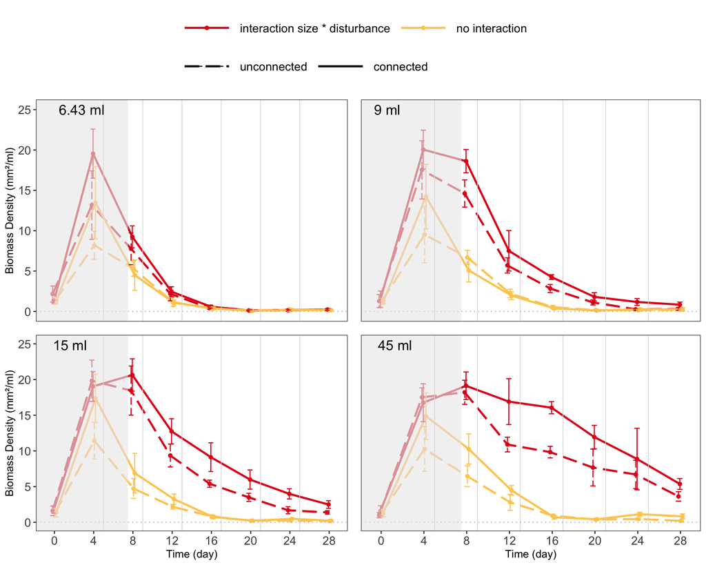

```r
# --- PLOT ONE PLOT PER ECOSYSTEM SIZE --- #

plot.metaecos.sizes.one.by.one.means(ds_metaecosystems,
                                     response_variable_selected,
                                     light_colour_metaecos,
                                     dark_colour_metaecos,
                                     y_upper_limit = 25)
```

```r
# --- PREPARE DATA FOR ANALYSIS --- #

# Add baselines

baseline = ds_metaecosystems %>%
  filter(time_point == time_point_of_baselines) %>%
  select(system_nr,
         all_of(response_variable_selected)) %>%
  rename(baseline = all_of(response_variable_selected))

data_for_analysis = ds_metaecosystems %>%
  left_join(baseline)

# Filter and mutate

data_for_analysis = data_for_analysis %>%
  filter(time_point %in% time_points_model,
         !is.na(!!sym(response_variable_selected)),
         connection == "connected" |
          ecosystems_combined %in% unconnected_metaecosystems_selected) %>%
  mutate(conn = factor(x = ifelse(connection == "connected",
                                  "con",
                                  "unconnected"),
                       levels = c("unconnected", "con")))
```

**Filtered data**

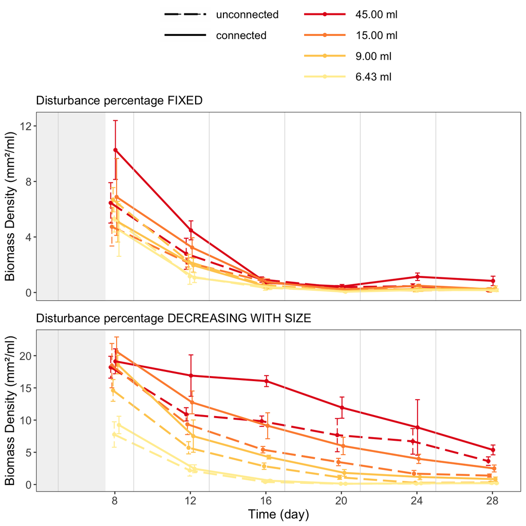

```r
# --- PLOT DATA FOR ANALYSIS --- #

ggarrange(plot.metaecos.legend(data_for_analysis %>%
                                 filter(disturbance_percentage == "fixed"),
                              response_variable_selected),
          plot.metaecos.points(data_for_analysis %>%
                                 filter(disturbance_percentage == "fixed"),
                               response_variable_selected)  +
            rremove("xlab") +
            theme(axis.text.x = element_blank(),
                  axis.ticks.x = element_blank(),
                  legend.position = "none") +
            font("legend.text", size = size_legend) +
            font("ylab", size = size_y_axis) +
            ggtitle(fixed_label),
          plot.metaecos.points(data_for_analysis %>%
                                 filter(disturbance_percentage == "decreasing_with_size"),
                               response_variable_selected)  +
            font("xlab", size = size_y_axis) +
            font("ylab", size = size_y_axis) +
            scale_x_continuous(breaks = unique(data_for_analysis$day)) +
            theme(legend.position = "none") +
            ggtitle(relative_label),
          heights = c(0.25, 0.6, 0.6),
          nrow = 3,
          align = "v")
```

```r
# --- CREATE MODEL --- #

# Prepare data

data_for_analysis = data_for_analysis %>%
  rename(size = ecosystem_size_ml,
         dis_per = disturbance_percentage) %>%
  mutate(size = as.factor(size),
         day = as.factor(day))

# Create model

model <- gls(bioarea_mm2_per_ml ~ size * conn * dis_per,
             weights = varIdent(form = ~ 1 | day),  # Allow variance heterogeneity across days
             correlation = corAR1(form = ~ 1 | day),  # Model autocorrelation if needed
             data = data_for_analysis,
             control = glsControl(opt = "optim", maxIter = 1000))
```

**Model summary**

```r
# --- SHOW MODEL SUMMARY --- #

print(summary(model), digits = 3)
```

```
## Generalized least squares fit by REML
##   Model: bioarea_mm2_per_ml ~ size * conn * dis_per
##   Data: data_for_analysis
##        AIC      BIC    logLik
##   1967.227 2066.769 -960.6134
##
## Correlation Structure: AR(1)
##  Formula: ~1 | day
##  Parameter estimate(s):
##       Phi
## 0.9045325
## Variance function:
##  Structure: Different standard deviations per stratum
##  Formula: ~1 | day
##  Parameter estimates:
##         8        12        16        20        24        28
## 1.0000000 0.5982781 0.2825009 0.3169145 0.4846082 0.2642367
##
## Coefficients:
##                                 Value Std.Error   t-value p-value
## (Intercept)                  0.745053 0.6855902  1.086732  0.2776
## size9                        1.006204 0.4388150  2.293003  0.0222
## size15                       3.698579 0.5931937  6.235028  0.0000
## size45                       6.824673 0.7027410  9.711504  0.0000
## conncon                     -0.418771 0.9920058 -0.422146  0.6731
## dis_perfixed                -0.145698 0.7482814 -0.194711  0.8457
## size9:conncon                1.391032 0.6254598  2.224015  0.0265
## size15:conncon               3.414777 0.8485201  4.024391  0.0001
## size45:conncon               4.202156 1.0031133  4.189114  0.0000
## size9:dis_perfixed          -0.821157 0.6331425 -1.296955  0.1952
## size15:dis_perfixed         -3.474574 0.8735600 -3.977487  0.0001
## size45:dis_perfixed         -6.289128 1.0540465 -5.966651  0.0000
## conncon:dis_perfixed        -0.040908 1.0260749 -0.039868  0.9682
## size9:conncon:dis_perfixed  -1.261354 0.9011879 -1.399657  0.1622
## size15:conncon:dis_perfixed -3.112304 1.2508902 -2.488071  0.0131
## size45:conncon:dis_perfixed -3.624583 1.5176490 -2.388288  0.0173
##
##  Correlation:
##                             (Intr) size9  size15 size45 conncn ds_prf sz9:cn
## size9                       -0.286
```

[output cut: 38 more lines]

```
## size45:conncon
## size9:dis_perfixed
## size15:dis_perfixed
## size45:dis_perfixed
## conncon:dis_perfixed
## size9:conncon:dis_perfixed
## size15:conncon:dis_perfixed
## size45:conncon:dis_perfixed  0.805
##
## Standardized residuals:
##         Min          Q1         Med          Q3         Max
## -3.79296000 -0.26984049 -0.02981527  0.68135678  2.92865271
##
## Residual standard error: 6.949817
## Degrees of freedom: 576 total; 560 residual
```

**Model ANOVA**

```r
# --- SHOW MODEL ANOVA --- #

car::Anova(model, type = "III")
```

```
## Analysis of Deviance Table (Type III tests)
##
## Response: bioarea_mm2_per_ml
##                   Df    Chisq Pr(>Chisq)
## (Intercept)        1   1.1810  0.2771553
## size               3 105.8302  < 2.2e-16 ***
## conn               1   0.1782  0.6729187
## dis_per            1   0.0379  0.8456194
## size:conn          3  19.4868  0.0002168 ***
## size:dis_per       3  41.6456  4.771e-09 ***
## conn:dis_per       1   0.0016  0.9681984
## size:conn:dis_per  3   6.8318  0.0774556 .
## ---
## Signif. codes:  0 '***' 0.001 '**' 0.01 '*' 0.05 '.' 0.1 ' ' 1
```

**Model contrasts coding**

```r
# --- CODE MODEL CONSTRASTS --- #

# Estimate marginal means (least-squares means)

emmeans_output = emmeans(model,
                         specs = ~  conn * dis_per * size,
                         adjust = "sidak",
                         bias.adj = TRUE,
                         lmer.df = "satterthwaite")

emmeans_output
```

```
##  conn        dis_per              size emmean    SE    df lower.CL upper.CL
##  unconnected decreasing_with_size 6.43  0.745 0.686  7.74   -2.138     3.63
##  con         decreasing_with_size 6.43  0.326 0.761 10.53   -2.564     3.22
##  unconnected fixed                6.43  0.599 0.667  6.04   -2.546     3.74
##  con         fixed                6.43  0.140 0.676  2.84   -6.206     6.49
##  unconnected decreasing_with_size 9     1.751 0.700 15.33   -0.693     4.20
##  con         decreasing_with_size 9     2.724 0.724 22.74    0.337     5.11
##  unconnected fixed                9     0.784 0.668  8.31   -1.949     3.52
##  con         fixed                9     0.454 0.671  8.10   -2.318     3.23
##  unconnected decreasing_with_size 15    4.444 0.724 14.61    1.894     6.99
##  con         decreasing_with_size 15    7.440 0.700  1.89   -6.658    21.54
##  unconnected fixed                15    0.823 0.671 11.03   -1.692     3.34
##  con         fixed                15    0.666 0.668  7.36   -2.202     3.53
##  unconnected decreasing_with_size 45    7.570 0.761 13.25    4.836    10.30
##  con         decreasing_with_size 45   11.353 0.686  1.81   -4.059    26.77
##  unconnected fixed                45    1.135 0.676  6.87   -1.860     4.13
##  con         fixed                45    1.253 0.667  5.93   -1.927     4.43
##
## Degrees-of-freedom method: satterthwaite
## Confidence level used: 0.95
## Conf-level adjustment: sidak method for 16 estimates
```

```r
# Give a name for each level which you want to compare

uncon_decr_6_43 = c(1, rep(0,15))
con_decr_6_43 = c(rep(0,1), 1, rep(0,14))
uncon_fix_6_43 = c(rep(0,2), 1, rep(0,13))
con_fix_6_43 = c(rep(0,3), 1, rep(0,12))
uncon_decr_9 = c(rep(0,4), 1, rep(0,11))
con_decr_9 = c(rep(0,5), 1, rep(0,10))
uncon_fix_9 = c(rep(0,6), 1, rep(0,9))
con_fix_9 = c(rep(0,7), 1, rep(0,8))
uncon_decr_15 = c(rep(0,8), 1, rep(0,7))
con_decr_15 = c(rep(0,9), 1, rep(0,6))
uncon_fix_15 = c(rep(0,10), 1, rep(0,5))
con_fix_15 = c(rep(0,11), 1, rep(0,4))
uncon_decr_45 = c(rep(0,12), 1, rep(0,3))
con_decr_45 = c(rep(0,13), 1, rep(0,2))
uncon_fix_45 = c(rep(0,14), 1, rep(0,1))
con_fix_45 = c(rep(0,15), 1)

# Compute the contrasts

n_of_digits = 3
contrasts = contrast(emmeans_output,
                     method = list("6.43 ml no interact" = con_fix_6_43 - uncon_fix_6_43,
                                   "6.43 ml with interact" = con_decr_6_43 - uncon_decr_6_43,
                                   "9.00 ml no interact" = con_fix_9 - uncon_fix_9,
                                   "9.00 ml with interact" = con_decr_9 - uncon_decr_9,
                                   "15.00 ml no interact" = con_fix_15 - uncon_fix_15,
                                   "15.00 ml with interact" = con_decr_15 - uncon_decr_15,
                                   "45.00 ml no interact" = con_fix_45 - uncon_fix_45,
                                   "45.00 ml with interact" = con_decr_45 - uncon_decr_45)) %>%
  as.data.frame() %>%
  mutate(p.value = round(p.value, digits = n_of_digits),
         estimate = round(estimate, digits = n_of_digits),
         SE = round(SE, digits = n_of_digits),
         df = round(df, digits = n_of_digits),
         t.ratio = round(t.ratio, digits = n_of_digits),
         e = "",
         e = ifelse(p.value > 0.1,
                           "",
                           e),
         e = ifelse(p.value < 0.05,
                           "*",
                           e),
         e = ifelse(p.value < 0.01,
                           "**",
                           e),
         e = ifelse(p.value < 0.001,
                           "***",
                           e)) %>%
  rename(" " = e)
```

```r
# --- SHOW MODEL CONTRASTS --- #

contrasts
```

```
##                 contrast estimate    SE     df t.ratio p.value
## 1    6.43 ml no interact   -0.460 0.745  2.099  -0.617   0.598
## 2  6.43 ml with interact   -0.419 0.992 14.365  -0.422   0.679
## 3    9.00 ml no interact   -0.330 0.744  4.383  -0.443   0.678
## 4  9.00 ml with interact    0.972 0.976 26.487   0.996   0.328
## 5   15.00 ml no interact   -0.157 0.744  4.808  -0.211   0.841
## 6 15.00 ml with interact    2.996 0.976  5.317   3.069   0.026 *
## 7   45.00 ml no interact    0.118 0.745  3.793   0.158   0.882
## 8 45.00 ml with interact    3.783 0.992  5.463   3.814   0.011 *
```

**Model residuals**

```r
# --- PLOT MODEL RESIDUALS --- #
```

## Ecosystems

### Biomass

```r
# --- DEFINE PARAMETERS --- #

response_variable_selected = "bioarea_mm2_per_ml"
```

```r
# --- PLOT ONE PLOT PER ECOSYSTEM SIZE --- #

# Plot heterotrophic ecosystems

print("Heterotrophic ecosystems")
```

```
## [1] "Heterotrophic ecosystems"
```

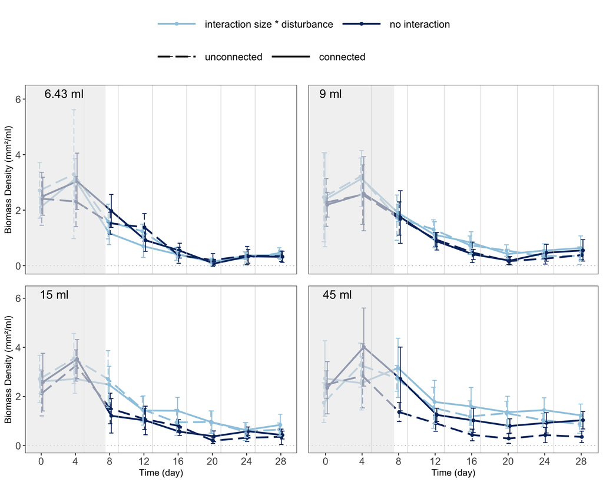

```r
plot.ecos.sizes.one.by.one.means(ds_ecosystems,
                                 "heterotrophic",
                                 response_variable_selected,
                                 light_colour_hetero,
                                 dark_colour_hetero,
                                 y_upper_limit = 6.2)
```

```r
# Plot autotrophic ecosystems

print("Autotrophic ecosystems")
```

```
## [1] "Autotrophic ecosystems"
```

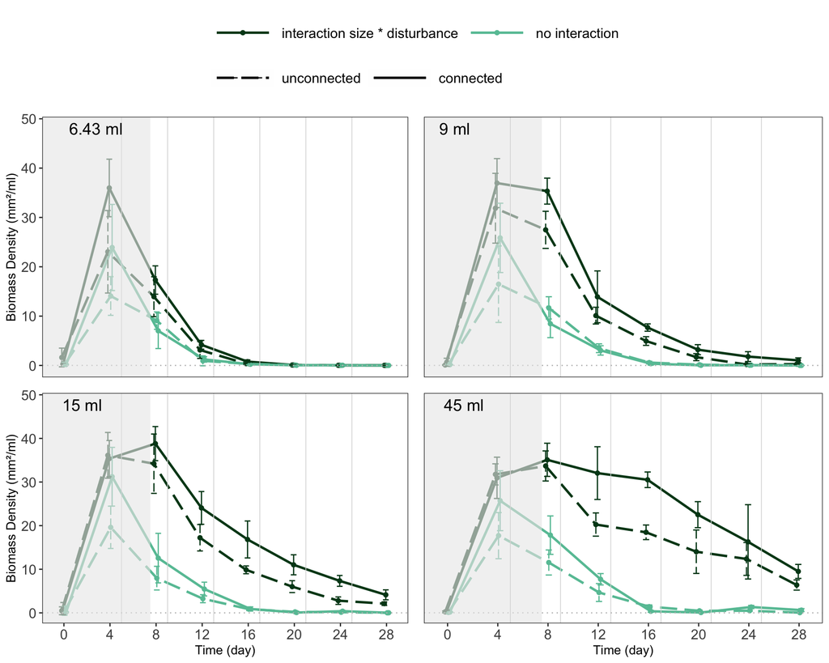

```r
plot.ecos.sizes.one.by.one.means(ds_ecosystems,
                                 "autotrophic",
                                 response_variable_selected,
                                 light_colour_auto,
                                 dark_colour_auto,
                                 y_upper_limit = 48)
```

```r
# --- PREPARE DATA FOR ANALYSIS --- #

# Add baselines

baseline = ds_ecosystems %>%
  filter(time_point == time_point_of_baselines) %>%
  select(ecosystem_ID,
         all_of(response_variable_selected)) %>%
  rename(baseline = all_of(response_variable_selected))

data_for_analysis = ds_ecosystems %>%
  left_join(baseline)

# Filter and mutate

data_for_analysis = data_for_analysis %>%
  filter(time_point %in% time_points_model,
         !is.na(!!sym(response_variable_selected))) %>%
  mutate(trophic_type = as.factor(trophic_type),
         size = as.factor(ecosystem_size_ml),
         conn = factor(x = ifelse(connection == "connected",
                                  "con",
                                  "unconnected"),
                       levels = c("unconnected", "con")),
         disturbance_percentage = as.factor(disturbance_percentage),
         day = as.double(day),
         ecosystem_ID = as.factor(ecosystem_ID))
```

```r
# --- CREATE MODEL --- #

# Prepare data

data_for_analysis = data_for_analysis %>%
  rename(dis_per = disturbance_percentage)

# Model

model <- glmmTMB(bioarea_mm2_per_ml ~
                   trophic_type * size * conn * dis_per +
                   (1 | ecosystem_ID) +
                   (1 | day) +
                   (1 | baseline),
                 data = data_for_analysis,
                 family = tweedie(link = "log"),
                 dispformula = ~ day + trophic_type + dis_per)
```

**Model summary**

```r
# --- SHOW MODEL SUMMARY --- #

print(summary(model), digits = 3)
```

```
##  Family: tweedie  ( log )
## Formula:
## bioarea_mm2_per_ml ~ trophic_type * size * conn * dis_per + (1 |
##     ecosystem_ID) + (1 | day) + (1 | baseline)
## Dispersion:                          ~day + trophic_type + dis_per
## Data: data_for_analysis
##
##      AIC      BIC   logLik deviance df.resid
##   2983.2   3185.2  -1451.6   2903.2     1112
##
## Random effects:
##
## Conditional model:
##  Groups       Name        Variance Std.Dev.
##  ecosystem_ID (Intercept) 1.1e-10  1.05e-05
##  day          (Intercept) 4.4e-01  6.63e-01
##  baseline     (Intercept) 1.1e-10  1.05e-05
## Number of obs: 1152, groups:  ecosystem_ID, 192; day, 6; baseline, 192
##
## Conditional model:
##                                                       Estimate Std. Error
## (Intercept)                                            0.70561    0.30329
## trophic_typeheterotrophic                             -1.33737    0.16037
## size9                                                  1.00799    0.16915
## size15                                                 1.54017    0.16594
## size45                                                 1.97221    0.16743
## conncon                                                0.25161    0.17766
## dis_perfixed                                          -0.53920    0.20423
## trophic_typeheterotrophic:size9                       -0.76179    0.20789
## trophic_typeheterotrophic:size15                      -0.92164    0.20260
## trophic_typeheterotrophic:size45                      -1.16126    0.20031
## trophic_typeheterotrophic:conncon                     -0.50661    0.21805
## size9:conncon                                          0.11035    0.23291
## size15:conncon                                         0.12946    0.22531
## size45:conncon                                         0.10475    0.21985
## trophic_typeheterotrophic:dis_perfixed                 0.56573    0.24339
## size9:dis_perfixed                                    -0.54479    0.27502
## size15:dis_perfixed                                   -1.29116    0.27491
## size45:dis_perfixed                                   -1.30883    0.26910
## conncon:dis_perfixed                                  -0.43931    0.28927
```

[output cut: 42 more lines]

```
## size45:conncon:dis_perfixed                              1.23  0.22043
## trophic_typeheterotrophic:size9:conncon:dis_perfixed    -0.01  0.99181
## trophic_typeheterotrophic:size15:conncon:dis_perfixed   -1.69  0.09137 .
## trophic_typeheterotrophic:size45:conncon:dis_perfixed   -0.31  0.75330
## ---
## Signif. codes:  0 '***' 0.001 '**' 0.01 '*' 0.05 '.' 0.1 ' ' 1
##
## Dispersion model:
##                           Estimate Std. Error z value Pr(>|z|)
## (Intercept)               -1.15318    0.17764   -6.49  8.5e-11 ***
## day                        0.05677    0.00845    6.72  1.8e-11 ***
## trophic_typeheterotrophic -1.18170    0.08419  -14.04  < 2e-16 ***
## dis_perfixed               0.26455    0.07876    3.36  0.00078 ***
## ---
## Signif. codes:  0 '***' 0.001 '**' 0.01 '*' 0.05 '.' 0.1 ' ' 1
```

**Model ANOVA**

```r
# --- SHOW MODEL ANOVA --- #

car::Anova(model, type = "III")
```

```
## Analysis of Deviance Table (Type III Wald chisquare tests)
##
## Response: bioarea_mm2_per_ml
##                                   Chisq Df Pr(>Chisq)
## (Intercept)                      5.4126  1   0.019992 *
## trophic_type                    69.5470  1  < 2.2e-16 ***
## size                           148.9871  3  < 2.2e-16 ***
## conn                             2.0058  1   0.156697
## dis_per                          6.9705  1   0.008286 **
## trophic_type:size               35.1991  3  1.106e-07 ***
## trophic_type:conn                5.3978  1   0.020162 *
## size:conn                        0.3637  3   0.947644
## trophic_type:dis_per             5.4027  1   0.020106 *
## size:dis_per                    32.5082  3  4.089e-07 ***
## conn:dis_per                     2.3064  1   0.128846
## trophic_type:size:conn           1.5494  3   0.670915
## trophic_type:size:dis_per        5.0831  3   0.165815
## trophic_type:conn:dis_per        3.6526  1   0.055983 .
## size:conn:dis_per                5.4426  3   0.142112
## trophic_type:size:conn:dis_per   4.2351  3   0.237167
## ---
## Signif. codes:  0 '***' 0.001 '**' 0.01 '*' 0.05 '.' 0.1 ' ' 1
```

**Model residuals coding**

```r
# --- CODE MODEL CONSTRASTS --- #

# Estimate marginal means (Least-squares means)

emmeans_output = emmeans(model,
                         specs = ~  conn * dis_per * size * trophic_type,  # Calculate emmeans for the interaction of conn, dis_per, size, and trophic_type
                         adjust = "sidak",  # Use Sidak adjustment for multiple comparisons
                         bias.adj = TRUE,  # Apply bias adjustment
                         lmer.df = "satterthwaite")  # Use Satterthwaite approximation for degrees of freedom

emmeans_output
```

```
##  conn        dis_per              size trophic_type   emmean    SE  df
##  unconnected decreasing_with_size 6.43 autotrophic    0.7056 0.303 Inf
##  con         decreasing_with_size 6.43 autotrophic    0.9572 0.301 Inf
##  unconnected fixed                6.43 autotrophic    0.1664 0.318 Inf
##  con         fixed                6.43 autotrophic   -0.0213 0.320 Inf
##  unconnected decreasing_with_size 9    autotrophic    1.7136 0.294 Inf
##  con         decreasing_with_size 9    autotrophic    2.0756 0.291 Inf
##  unconnected fixed                9    autotrophic    0.6296 0.312 Inf
##  con         fixed                9    autotrophic    0.3423 0.315 Inf
##  unconnected decreasing_with_size 15   autotrophic    2.2458 0.290 Inf
##  con         decreasing_with_size 15   autotrophic    2.6269 0.287 Inf
##  unconnected fixed                15   autotrophic    0.4154 0.313 Inf
##  con         fixed                15   autotrophic    0.8468 0.309 Inf
##  unconnected decreasing_with_size 45   autotrophic    2.6778 0.287 Inf
##  con         decreasing_with_size 45   autotrophic    3.0342 0.285 Inf
##  unconnected fixed                45   autotrophic    0.8298 0.308 Inf
##  con         fixed                45   autotrophic    1.2042 0.305 Inf
##  unconnected decreasing_with_size 6.43 heterotrophic -0.6318 0.285 Inf
##  con         decreasing_with_size 6.43 heterotrophic -0.8868 0.286 Inf
##  unconnected fixed                6.43 heterotrophic -0.6052 0.289 Inf
##  con         fixed                6.43 heterotrophic -0.6384 0.289 Inf
##  unconnected decreasing_with_size 9    heterotrophic -0.3856 0.284 Inf
##  con         decreasing_with_size 9    heterotrophic -0.3209 0.284 Inf
##  unconnected fixed                9    heterotrophic -0.6845 0.289 Inf
##  con         fixed                9    heterotrophic -0.6128 0.289 Inf
##  unconnected decreasing_with_size 15   heterotrophic -0.0132 0.282 Inf
##  con         decreasing_with_size 15   heterotrophic  0.0590 0.282 Inf
##  unconnected fixed                15   heterotrophic -0.5673 0.289 Inf
##  con         fixed                15   heterotrophic -0.5675 0.289 Inf
##  unconnected decreasing_with_size 45   heterotrophic  0.1792 0.282 Inf
##  con         decreasing_with_size 45   heterotrophic  0.3711 0.282 Inf
##  unconnected fixed                45   heterotrophic -0.6953 0.289 Inf
##  con         fixed                45   heterotrophic  0.0334 0.286 Inf
##  asymp.LCL asymp.UCL
##   -0.25146    1.6627
##    0.00728    1.9072
##   -0.83708    1.1699
##   -1.03144    0.9889
##    0.78610    2.6411
##    1.15717    2.9939
```

[output cut: 15 more lines]

```
##   -1.21584    0.5740
##   -1.59708    0.2281
##   -1.52399    0.2983
##   -0.90449    0.8780
##   -0.83182    0.9497
##   -1.47774    0.3431
##   -1.47838    0.3433
##   -0.71073    1.0691
##   -0.51724    1.2594
##   -1.60782    0.2173
##   -0.86839    0.9352
##
## Results are given on the log (not the response) scale.
## Confidence level used: 0.95
## Conf-level adjustment: sidak method for 32 estimates
```

```r
# Define contrast vectors for each group

aut_uncon_decr_6_43 = c(1, rep(0,31))  # Autotrophic, unconnected, 6.43 ml decrease
aut_con_decr_6_43 = c(rep(0,1), 1, rep(0,30))  # Autotrophic, connected, 6.43 ml decrease
aut_uncon_fix_6_43 = c(rep(0,2), 1, rep(0,29))  # Autotrophic, unconnected, 6.43 ml fixed
aut_con_fix_6_43 = c(rep(0,3), 1, rep(0,28))  # Autotrophic, connected, 6.43 ml fixed
aut_uncon_decr_9 = c(rep(0,4), 1, rep(0,27))  # Autotrophic, unconnected, 9.00 ml decrease
aut_con_decr_9 = c(rep(0,5), 1, rep(0,26))  # Autotrophic, connected, 9.00 ml decrease
aut_uncon_fix_9 = c(rep(0,6), 1, rep(0,25))  # Autotrophic, unconnected, 9.00 ml fixed
aut_con_fix_9 = c(rep(0,7), 1, rep(0,24))  # Autotrophic, connected, 9.00 ml fixed
aut_uncon_decr_15 = c(rep(0,8), 1, rep(0,23))  # Autotrophic, unconnected, 15.00 ml decrease
aut_con_decr_15 = c(rep(0,9), 1, rep(0,22))  # Autotrophic, connected, 15.00 ml decrease
aut_uncon_fix_15 = c(rep(0,10), 1, rep(0,21))  # Autotrophic, unconnected, 15.00 ml fixed
aut_con_fix_15 = c(rep(0,11), 1, rep(0,20))  # Autotrophic, connected, 15.00 ml fixed
aut_uncon_decr_45 = c(rep(0,12), 1, rep(0,19))  # Autotrophic, unconnected, 45.00 ml decrease
aut_con_decr_45 = c(rep(0,13), 1, rep(0,18))  # Autotrophic, connected, 45.00 ml decrease
aut_uncon_fix_45 = c(rep(0,14), 1, rep(0,17))  # Autotrophic, unconnected, 45.00 ml fixed
aut_con_fix_45 = c(rep(0,15), 1, rep(0,16))  # Autotrophic, connected, 45.00 ml fixed

# Same pattern for heterotrophic group

het_uncon_decr_6_43 = c(rep(0,16), 1, rep(0,15))  # Heterotrophic, unconnected, 6.43 ml decrease
het_con_decr_6_43 = c(rep(0,17), 1, rep(0,14))  # Heterotrophic, connected, 6.43 ml decrease
het_uncon_fix_6_43 = c(rep(0,18), 1, rep(0,13))  # Heterotrophic, unconnected, 6.43 ml fixed
het_con_fix_6_43 = c(rep(0,19), 1, rep(0,12))  # Heterotrophic, connected, 6.43 ml fixed
het_uncon_decr_9 = c(rep(0,20), 1, rep(0,11))  # Heterotrophic, unconnected, 9.00 ml decrease
het_con_decr_9 = c(rep(0,21), 1, rep(0,10))  # Heterotrophic, connected, 9.00 ml decrease
het_uncon_fix_9 = c(rep(0,22), 1, rep(0,9))  # Heterotrophic, unconnected, 9.00 ml fixed
het_con_fix_9 = c(rep(0,23), 1, rep(0,8))  # Heterotrophic, connected, 9.00 ml fixed
het_uncon_decr_15 = c(rep(0,24), 1, rep(0,7))  # Heterotrophic, unconnected, 15.00 ml decrease
het_con_decr_15 = c(rep(0,25), 1, rep(0,6))  # Heterotrophic, connected, 15.00 ml decrease
het_uncon_fix_15 = c(rep(0,26), 1, rep(0,5))  # Heterotrophic, unconnected, 15.00 ml fixed
het_con_fix_15 = c(rep(0,27), 1, rep(0,4))  # Heterotrophic, connected, 15.00 ml fixed
het_uncon_decr_45 = c(rep(0,28), 1, rep(0,3))  # Heterotrophic, unconnected, 45.00 ml decrease
het_con_decr_45 = c(rep(0,29), 1, rep(0,2))  # Heterotrophic, connected, 45.00 ml decrease
het_uncon_fix_45 = c(rep(0,30), 1, rep(0,1))  # Heterotrophic, unconnected, 45.00 ml fixed
het_con_fix_45 = c(rep(0,31), 1)  # Heterotrophic, connected, 45.00 ml fixed

n_of_digits = 3  # Set number of digits for rounding

# Calculate contrasts using the defined vectors

contrasts = contrast(emmeans_output,
                     method = list("Het 6.43 ml no interact" = het_con_fix_6_43 - het_uncon_fix_6_43,
                                   "Het 6.43 ml with interact" = het_con_decr_6_43 - het_uncon_decr_6_43,
                                   "Het 9.00 ml no interact" = het_con_fix_9 - het_uncon_fix_9,
                                   "Het 9.00 ml with interact" = het_con_decr_9 - het_uncon_decr_9,
                                   "Het 15.00 ml no interact" = het_con_fix_15 - het_uncon_fix_15,
                                   "Het 15.00 ml with interact" = het_con_decr_15 - het_uncon_decr_15,
                                   "Het 45.00 ml no interact" = het_con_fix_45 - het_uncon_fix_45,
                                   "Het 45.00 ml with interact" = het_con_decr_45 - het_uncon_decr_45,
                                   "Aut 6.43 ml no interact" = aut_con_fix_6_43 - aut_uncon_fix_6_43,
                                   "Aut 6.43 ml with interact" = aut_con_decr_6_43 - aut_uncon_decr_6_43,
                                   "Aut 9.00 ml no interact" = aut_con_fix_9 - aut_uncon_fix_9,
                                   "Aut 9.00 ml with interact" = aut_con_decr_9 - aut_uncon_decr_9,
                                   "Aut 15.00 ml no interact" = aut_con_fix_15 - aut_uncon_fix_15,
                                   "Aut 15.00 ml with interact" = aut_con_decr_15 - aut_uncon_decr_15,
                                   "Aut 45.00 ml no interact" = aut_con_fix_45 - aut_uncon_fix_45,
                                   "Aut 45.00 ml with interact" = aut_con_decr_45 - aut_uncon_decr_45)) %>%
  as.data.frame() %>%  # Convert the contrast output to a data frame
  mutate(p.value = round(p.value, digits = n_of_digits),  # Round p-value to specified digits
         estimate = round(estimate, digits = n_of_digits),  # Round estimate
         SE = round(SE, digits = n_of_digits),  # Round standard error
         df = round(df, digits = n_of_digits),  # Round degrees of freedom
         z.ratio = round(z.ratio, digits = n_of_digits),  # Round t-ratio (z.ratio)
         e = "",  # Initialize a column for significance indicators
         e = ifelse(p.value > 0.1,
                           "",  # No symbol if p-value > 0.1
                           e),
         e = ifelse(p.value < 0.05,
                           "*",  # Add * if p-value < 0.05
                           e),
         e = ifelse(p.value < 0.01,
                           "**",  # Add ** if p-value < 0.01
                           e),
         e = ifelse(p.value < 0.001,
                           "***",  # Add *** if p-value < 0.001
                           e)) %>%
  rename(" " = e)  # Rename column to show significance markers
```

```r
# --- SHOW MODEL CONTRASTS --- #

contrasts
```

```
##                      contrast estimate    SE  df z.ratio p.value
## 1     Het 6.43 ml no interact   -0.033 0.141 Inf  -0.235   0.814
## 2   Het 6.43 ml with interact   -0.255 0.127 Inf  -2.015   0.044   *
## 3     Het 9.00 ml no interact    0.072 0.142 Inf   0.505   0.613
## 4   Het 9.00 ml with interact    0.065 0.119 Inf   0.545   0.586
## 5    Het 15.00 ml no interact    0.000 0.140 Inf  -0.002   0.999
## 6  Het 15.00 ml with interact    0.072 0.112 Inf   0.646   0.518
## 7    Het 45.00 ml no interact    0.729 0.135 Inf   5.382   0.000 ***
## 8  Het 45.00 ml with interact    0.192 0.107 Inf   1.788   0.074
## 9     Aut 6.43 ml no interact   -0.188 0.228 Inf  -0.822   0.411
## 10  Aut 6.43 ml with interact    0.252 0.178 Inf   1.416   0.157
## 11    Aut 9.00 ml no interact   -0.287 0.214 Inf  -1.342   0.180
## 12  Aut 9.00 ml with interact    0.362 0.151 Inf   2.402   0.016   *
## 13   Aut 15.00 ml no interact    0.431 0.209 Inf   2.060   0.039   *
## 14 Aut 15.00 ml with interact    0.381 0.139 Inf   2.748   0.006  **
## 15   Aut 45.00 ml no interact    0.374 0.197 Inf   1.900   0.057
## 16 Aut 45.00 ml with interact    0.356 0.130 Inf   2.751   0.006  **
```

**Model residuals**

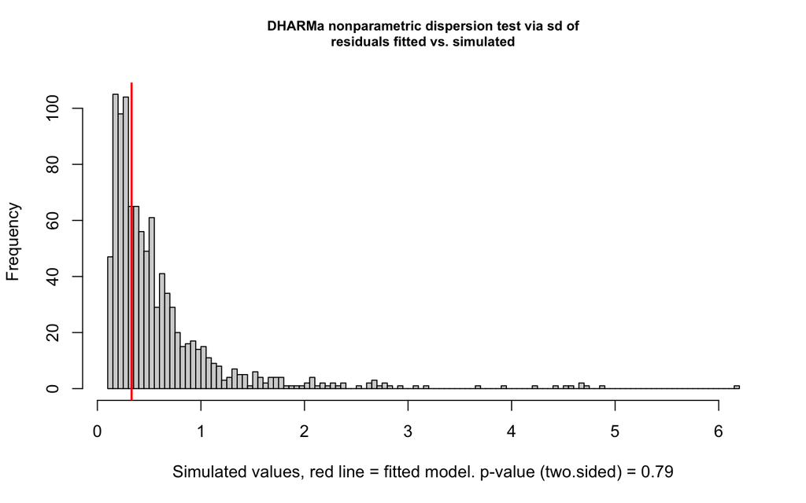

```
##
##  DHARMa nonparametric dispersion test via sd of residuals fitted vs.
##  simulated
##
## data:  simulationOutput
## dispersion = 0.54769, p-value = 0.79
## alternative hypothesis: two.sided
```

```r
# --- PLOT MODEL RESIDUALS --- #

# Simulate residuals from the fitted model

simulationOutput <- simulateResiduals(fittedModel = model,
                                      n = 1000)

# Test for overdispersion in the model to check if variance exceeds mean

testDispersion(simulationOutput)
```

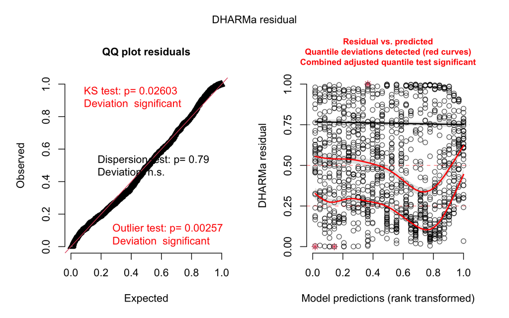

```r
# Plot Q-Q and Residuals vs Fitted plots

plot(simulationOutput)
```

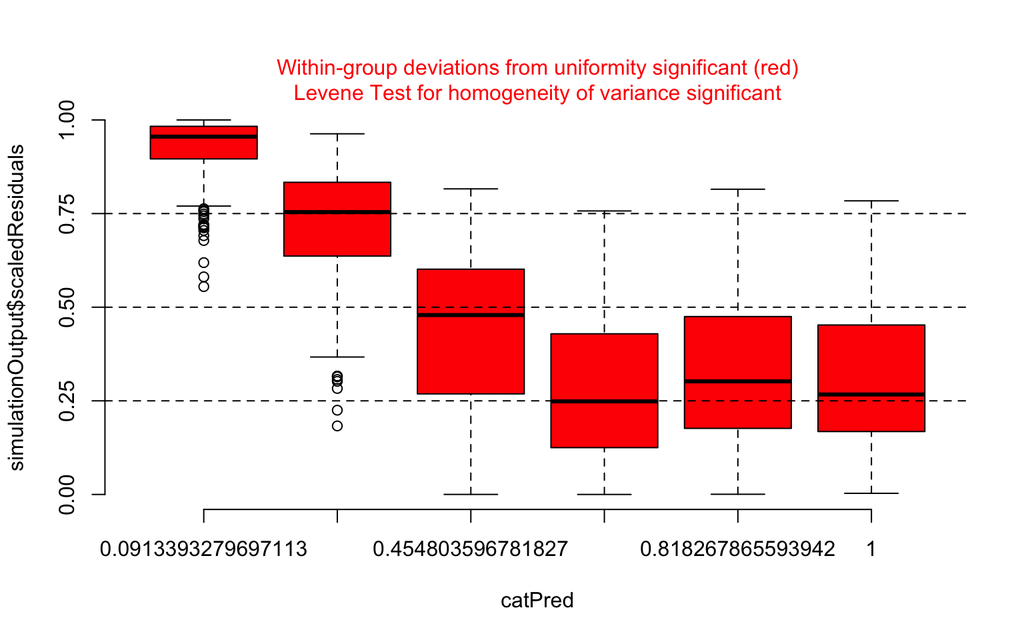

```r
# Plot residuals against specific predictors to check if residuals are
# independent of these variables

plotResiduals(simulationOutput,
              form = data_for_analysis$day)
```

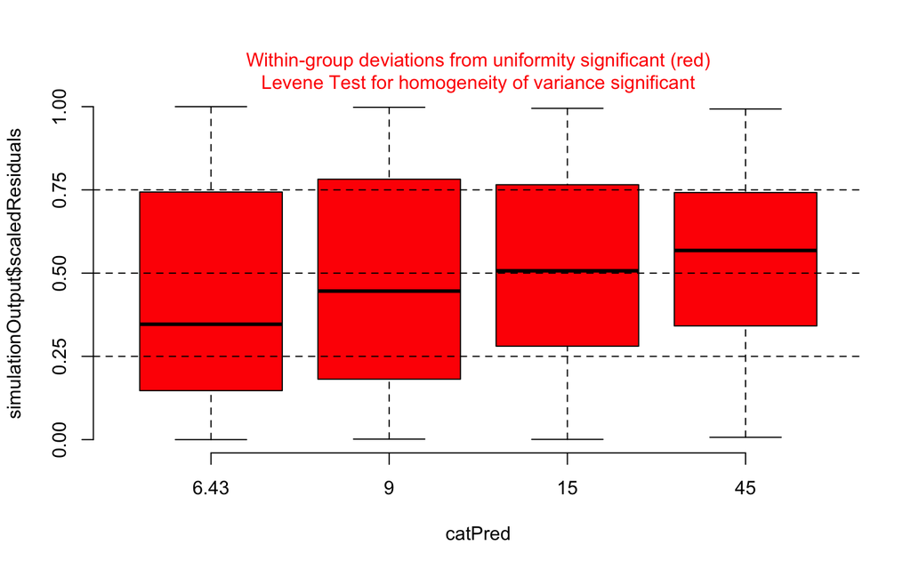

```r
plotResiduals(simulationOutput,
              form = data_for_analysis$size)
```

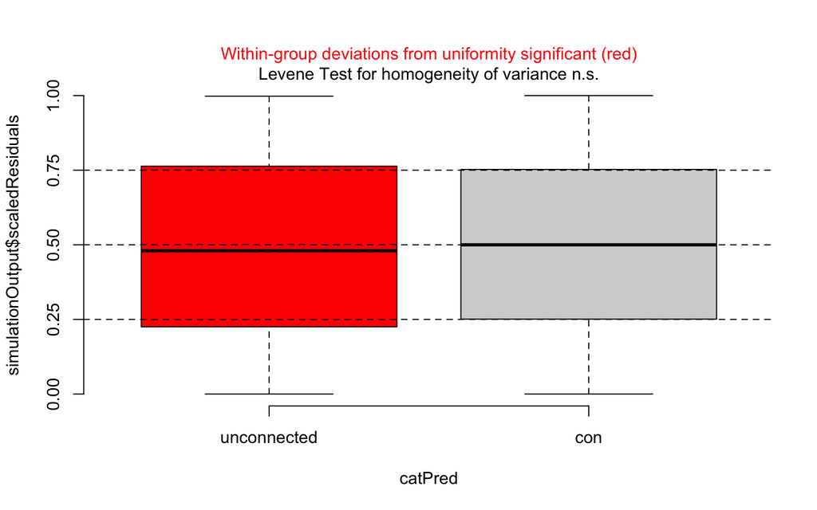

```r
plotResiduals(simulationOutput,
              form = data_for_analysis$conn)
```

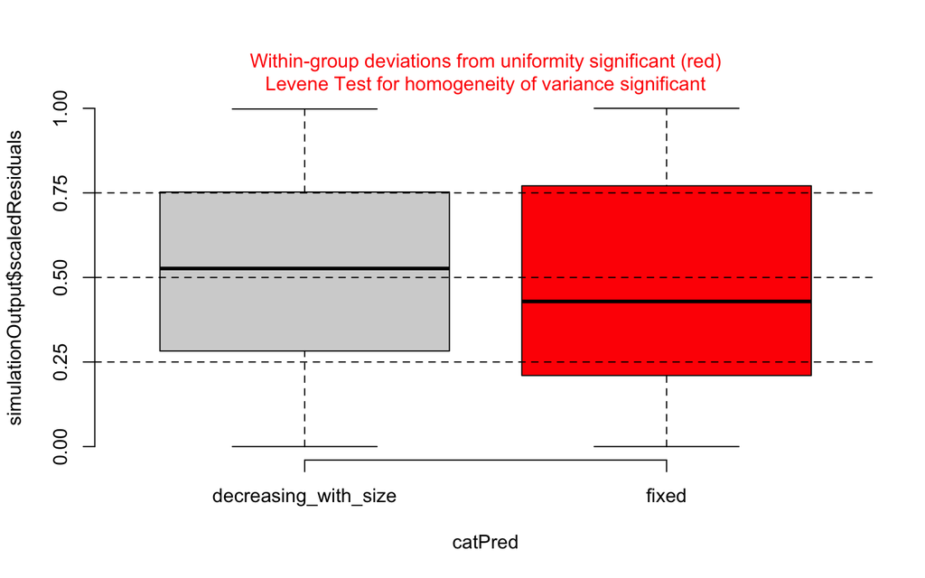

```r
plotResiduals(simulationOutput,
              form = data_for_analysis$dis_per)
```

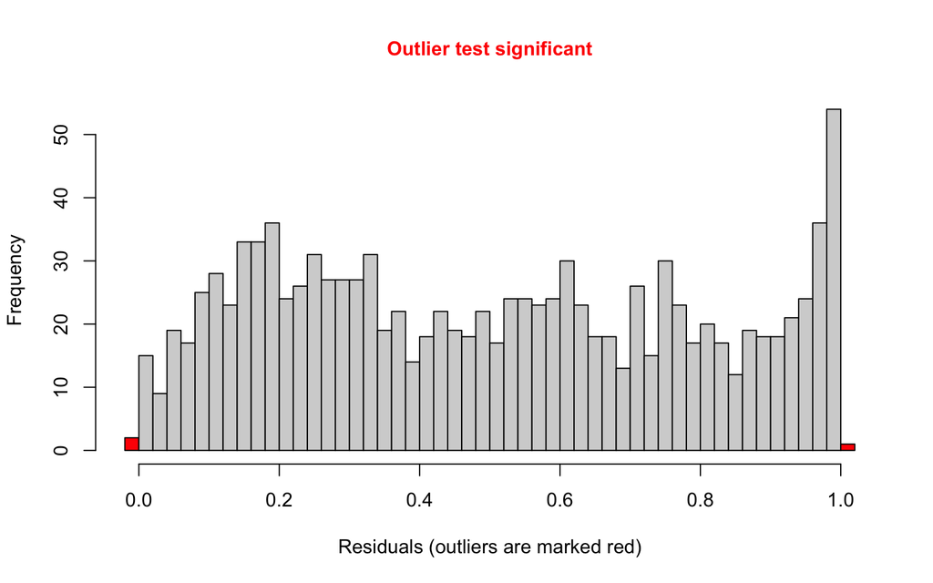

```
##
##  DHARMa outlier test based on exact binomial test with approximate
##  expectations
##
## data:  simulationOutput
## outliers at both margin(s) = 8, observations = 1152, p-value = 0.002569
## alternative hypothesis: true probability of success is not equal to 0.001998002
## 95 percent confidence interval:
##  0.003002746 0.013637249
## sample estimates:
## frequency of outliers (expected: 0.001998001998002 )
##                                          0.006944444
```

```r
# Test for outliers

testOutliers(simulationOutput)
```

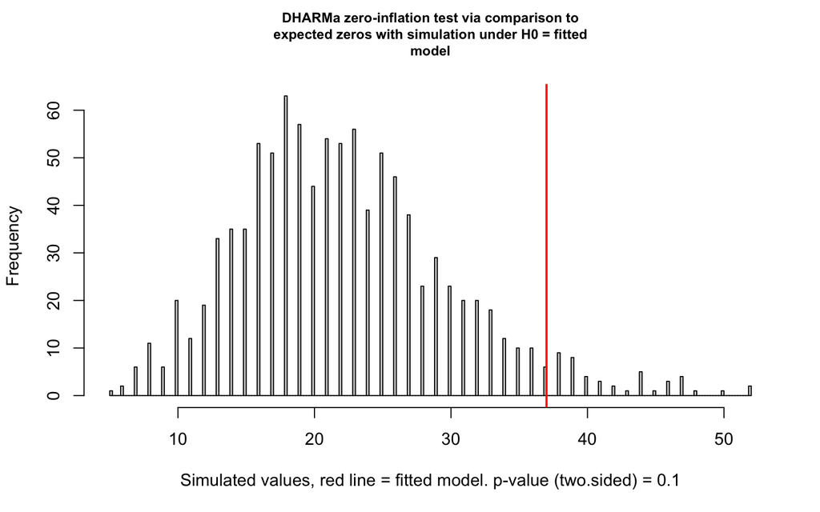

```
##
##  DHARMa zero-inflation test via comparison to expected zeros with
##  simulation under H0 = fitted model
##
## data:  simulationOutput
## ratioObsSim = 1.6619, p-value = 0.1
## alternative hypothesis: two.sided
```

```r
# Test for zero inflation not accounted for

testZeroInflation(simulationOutput)
```

### Shannon

```r
# --- DEFINE PARAMETERS --- #

response_variable_selected = "shannon"
```

```r
# --- PLOT ONE PLOT PER ECOSYSTEM SIZE --- #

# Plot heterotrophic ecosystems

print("Heterotrophic ecosystems")
```

```
## [1] "Heterotrophic ecosystems"
```

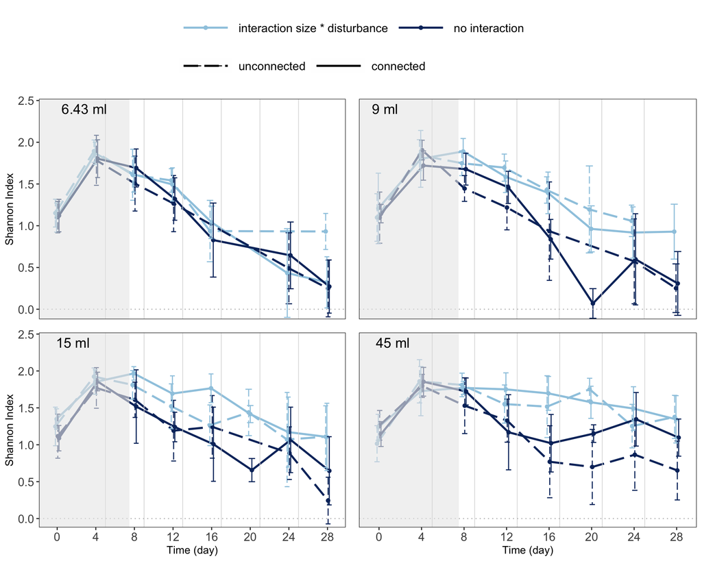

```r
plot.ecos.sizes.one.by.one.means(ds_ecosystems,
                                 "heterotrophic",
                                 response_variable_selected,
                                 light_colour_hetero,
                                 dark_colour_hetero,
                                 y_upper_limit = 2.4)
```

```r
# --- PREPARE DATA FOR ANALYSIS --- #

# Add baselines

baseline = ds_ecosystems %>%
  filter(time_point == time_point_of_baselines) %>%
  select(ecosystem_ID,
         all_of(response_variable_selected)) %>%
  rename(baseline = all_of(response_variable_selected))

data_for_analysis = ds_ecosystems %>%
  left_join(baseline)

# Filter and mutate

data_for_analysis = data_for_analysis %>%
  filter(time_point %in% time_points_model,
         !is.na(!!sym(response_variable_selected))) %>%
  mutate(trophic_type = as.factor(trophic_type),
         size = as.factor(ecosystem_size_ml),
         conn = factor(x = ifelse(connection == "connected",
                                  "con",
                                  "unconnected"),
                       levels = c("unconnected", "con")),
         disturbance_percentage = as.factor(disturbance_percentage),
         day = as.double(day),
         ecosystem_ID = as.factor(ecosystem_ID))
```

```r
# --- CREATE MODEL --- #

# Prepare data

data_for_analysis = data_for_analysis %>%
  rename(dis_per = disturbance_percentage) %>%
  filter(trophic_type == "heterotrophic")

# Model

model = glmmTMB(shannon ~
                  size * conn * dis_per +
                  (1 | ecosystem_ID) +
                  (1 | day) +
                  (1 | baseline),
                data = data_for_analysis,
                family = tweedie(link = "log"),
                ziformula = ~ size * conn * dis_per,
                dispformula = ~ size + conn + dis_per + day,
                control=glmmTMBControl(optimizer=nlminb,
                                       optArgs=list(method="BFGS")))
```

**Model summary**

```r
# --- SHOW MODEL SUMMARY --- #

print(summary(model), digits = 3)
```

```
##  Family: tweedie  ( log )
## Formula:
## shannon ~ size * conn * dis_per + (1 | ecosystem_ID) + (1 | day) +
##     (1 | baseline)
## Zero inflation:           ~size * conn * dis_per
## Dispersion:               ~size + conn + dis_per + day
## Data: data_for_analysis
##
##      AIC      BIC   logLik deviance df.resid
##    595.9    782.5   -255.0    509.9      523
##
## Random effects:
##
## Conditional model:
##  Groups       Name        Variance Std.Dev.
##  ecosystem_ID (Intercept) 5.19e-14 2.28e-07
##  day          (Intercept) 4.87e-02 2.21e-01
##  baseline     (Intercept) 5.19e-14 2.28e-07
## Number of obs: 566, groups:  ecosystem_ID, 96; day, 6; baseline, 96
##
## Conditional model:
##                             Estimate Std. Error z value Pr(>|z|)
## (Intercept)                  0.10060        NaN     NaN      NaN
## size9                        0.16857        NaN     NaN      NaN
## size15                       0.17890        NaN     NaN      NaN
## size45                       0.24928        NaN     NaN      NaN
## conncon                     -0.01069        NaN     NaN      NaN
## dis_perfixed                -0.10905        NaN     NaN      NaN
## size9:conncon               -0.00984        NaN     NaN      NaN
## size15:conncon               0.11275        NaN     NaN      NaN
## size45:conncon               0.04855        NaN     NaN      NaN
## size9:dis_perfixed          -0.15067        NaN     NaN      NaN
## size15:dis_perfixed         -0.12519        NaN     NaN      NaN
## size45:dis_perfixed         -0.20444        NaN     NaN      NaN
## conncon:dis_perfixed         0.09189        NaN     NaN      NaN
## size9:conncon:dis_perfixed   0.00697        NaN     NaN      NaN
## size15:conncon:dis_perfixed -0.22483        NaN     NaN      NaN
## size45:conncon:dis_perfixed -0.01317        NaN     NaN      NaN
##
## Zero-inflation model:
```

[output cut: 12 more lines]

```
## size45:dis_perfixed          16.1909        NaN     NaN      NaN
## conncon:dis_perfixed         -1.8556        NaN     NaN      NaN
## size9:conncon:dis_perfixed   26.6592        NaN     NaN      NaN
## size15:conncon:dis_perfixed   0.1555        NaN     NaN      NaN
## size45:conncon:dis_perfixed  -9.4557        NaN     NaN      NaN
##
## Dispersion model:
##              Estimate Std. Error z value Pr(>|z|)
## (Intercept)   -3.9914        NaN     NaN      NaN
## size9         -0.3736        NaN     NaN      NaN
## size15         0.1238        NaN     NaN      NaN
## size45         0.0458        NaN     NaN      NaN
## conncon       -0.0848        NaN     NaN      NaN
## dis_perfixed   0.4651        NaN     NaN      NaN
## day            0.0726        NaN     NaN      NaN
```

**Model ANOVA**

```r
# --- SHOW MODEL ANOVA --- #

car::Anova(model, type = "III")
```

```
## Analysis of Deviance Table (Type III Wald chisquare tests)
##
## Response: shannon
##                   Chisq Df Pr(>Chisq)
## (Intercept)         NaN  1        NaN
## size                NaN  3        NaN
## conn                NaN  1        NaN
## dis_per             NaN  1        NaN
## size:conn           NaN  3        NaN
## size:dis_per        NaN  3        NaN
## conn:dis_per        NaN  1        NaN
## size:conn:dis_per   NaN  3        NaN
```

**Model residuals coding**

```r
# --- CODE MODEL CONSTRASTS --- #

# Estimate marginal means (Least-squares means)

emmeans_output = emmeans(model,
                         specs = ~  conn * dis_per * size,  # Calculate emmeans for the interaction of conn, dis_per, and size
                         adjust = "sidak",  # Use Sidak adjustment for multiple comparisons
                         bias.adj = TRUE,  # Apply bias adjustment
                         lmer.df = "satterthwaite")  # Use Satterthwaite approximation for degrees of freedom

emmeans_output
```

```
##  conn        dis_per              size   emmean  SE  df asymp.LCL asymp.UCL
##  unconnected decreasing_with_size 6.43  0.10060 NaN Inf       NaN       NaN
##  con         decreasing_with_size 6.43  0.08991 NaN Inf       NaN       NaN
##  unconnected fixed                6.43 -0.00845 NaN Inf       NaN       NaN
##  con         fixed                6.43  0.07275 NaN Inf       NaN       NaN
##  unconnected decreasing_with_size 9     0.26918 NaN Inf       NaN       NaN
##  con         decreasing_with_size 9     0.24865 NaN Inf       NaN       NaN
##  unconnected fixed                9     0.00945 NaN Inf       NaN       NaN
##  con         fixed                9     0.08779 NaN Inf       NaN       NaN
##  unconnected decreasing_with_size 15    0.27950 NaN Inf       NaN       NaN
##  con         decreasing_with_size 15    0.38156 NaN Inf       NaN       NaN
##  unconnected fixed                15    0.04526 NaN Inf       NaN       NaN
##  con         fixed                15    0.01438 NaN Inf       NaN       NaN
##  unconnected decreasing_with_size 45    0.34988 NaN Inf       NaN       NaN
##  con         decreasing_with_size 45    0.38774 NaN Inf       NaN       NaN
##  unconnected fixed                45    0.03638 NaN Inf       NaN       NaN
##  con         fixed                45    0.15296 NaN Inf       NaN       NaN
##
## Results are given on the log (not the response) scale.
## Confidence level used: 0.95
## Conf-level adjustment: sidak method for 16 estimates
```

```r
# Define contrast vectors for each group

uncon_decr_6_43 = c(1, rep(0,15)) # Autotrophic, unconnected, 6.43 ml decrease
con_decr_6_43 = c(rep(0,1), 1, rep(0,14)) # Autotrophic, connected, 6.43 ml decrease
uncon_fix_6_43 = c(rep(0,2), 1, rep(0,13)) # Autotrophic, unconnected, 6.43 ml fixed
con_fix_6_43 = c(rep(0,3), 1, rep(0,12)) # Autotrophic, connected, 6.43 ml fixed
uncon_decr_9 = c(rep(0,4), 1, rep(0,11)) # Autotrophic, unconnected, 9.00 ml decrease
con_decr_9 = c(rep(0,5), 1, rep(0,10)) # Autotrophic, connected, 9.00 ml decrease
uncon_fix_9 = c(rep(0,6), 1, rep(0,9)) # Autotrophic, unconnected, 9.00 ml fixed
con_fix_9 = c(rep(0,7), 1, rep(0,8)) # Autotrophic, connected, 9.00 ml fixed
uncon_decr_15 = c(rep(0,8), 1, rep(0,7)) # Autotrophic, unconnected, 15.00 ml decrease
con_decr_15 = c(rep(0,9), 1, rep(0,6)) # Autotrophic, connected, 15.00 ml decrease
uncon_fix_15 = c(rep(0,10), 1, rep(0,5)) # Autotrophic, unconnected, 15.00 ml fixed
con_fix_15 = c(rep(0,11), 1, rep(0,4)) # Autotrophic, connected, 15.00 ml fixed
uncon_decr_45 = c(rep(0,12), 1, rep(0,3)) # Autotrophic, unconnected, 45.00 ml decrease
con_decr_45 = c(rep(0,13), 1, rep(0,2)) # Autotrophic, connected, 45.00 ml decrease
uncon_fix_45 = c(rep(0,14), 1, rep(0,1)) # Autotrophic, unconnected, 45.00 ml fixed
con_fix_45 = c(rep(0,15), 1) # Autotrophic, connected, 45.00 ml fixed

n_of_digits = 3 # Set number of digits for rounding

# Calculate contrasts using the defined vectors

contrasts = contrast(emmeans_output,
                     method = list("6.43 ml no interact" = con_fix_6_43 - uncon_fix_6_43,
                                   "6.43 ml with interact" = con_decr_6_43 - uncon_decr_6_43,
                                   "9.00 ml no interact" = con_fix_9 - uncon_fix_9,
                                   "9.00 ml with interact" = con_decr_9 - uncon_decr_9,
                                   "15.00 ml no interact" = con_fix_15 - uncon_fix_15,
                                   "15.00 ml with interact" = con_decr_15 - uncon_decr_15,
                                   "45.00 ml no interact" = con_fix_45 - uncon_fix_45,
                                   "45.00 ml with interact" = con_decr_45 - uncon_decr_45)) %>%
  as.data.frame() %>%  # Convert the contrast output to a data frame
  mutate(p.value = round(p.value, digits = n_of_digits),  # Round p-value to specified digits
         estimate = round(estimate, digits = n_of_digits),  # Round estimate
         SE = round(SE, digits = n_of_digits),  # Round standard error
         df = round(df, digits = n_of_digits),  # Round degrees of freedom
         t.ratio = round(z.ratio, digits = n_of_digits),  # Round t-ratio (z.ratio)
         e = "",  # Initialize a column for significance indicators
         e = ifelse(p.value > 0.1,
                           "",  # No symbol if p-value > 0.1
                           e),
         e = ifelse(p.value < 0.05,
                           "*",  # Add * if p-value < 0.05
                           e),
         e = ifelse(p.value < 0.01,
                           "**",  # Add ** if p-value < 0.01
                           e),
         e = ifelse(p.value < 0.001,
                           "***",  # Add *** if p-value < 0.001
                           e)) %>%
  rename(" " = e)  # Rename column to show significance markers
```

```r
# --- SHOW MODEL CONTRASTS --- #

contrasts
```

```
##                 contrast estimate  SE  df z.ratio p.value t.ratio
## 1    6.43 ml no interact    0.081 NaN Inf     NaN     NaN     NaN NA
## 2  6.43 ml with interact   -0.011 NaN Inf     NaN     NaN     NaN NA
## 3    9.00 ml no interact    0.078 NaN Inf     NaN     NaN     NaN NA
## 4  9.00 ml with interact   -0.021 NaN Inf     NaN     NaN     NaN NA
## 5   15.00 ml no interact   -0.031 NaN Inf     NaN     NaN     NaN NA
## 6 15.00 ml with interact    0.102 NaN Inf     NaN     NaN     NaN NA
## 7   45.00 ml no interact    0.117 NaN Inf     NaN     NaN     NaN NA
## 8 45.00 ml with interact    0.038 NaN Inf     NaN     NaN     NaN NA
```

**Model residuals**

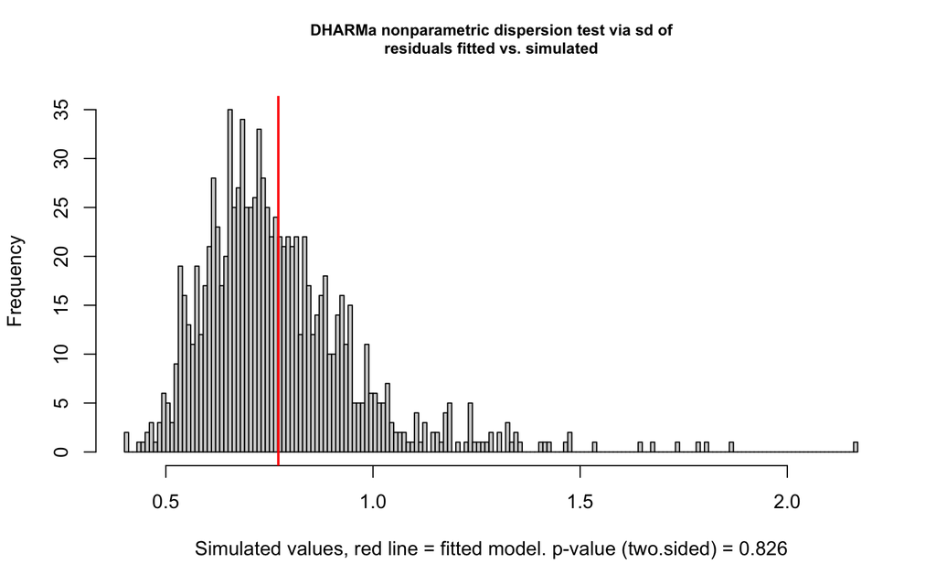

```
##
##  DHARMa nonparametric dispersion test via sd of residuals fitted vs.
##  simulated
##
## data:  simulationOutput
## dispersion = 0.99864, p-value = 0.826
## alternative hypothesis: two.sided
```

```r
# --- PLOT MODEL RESIDUALS --- #

# Simulate residuals from the fitted model

simulationOutput <- simulateResiduals(fittedModel = model,
                                      n = 1000)

# Test for overdispersion in the model to check if variance exceeds mean

testDispersion(simulationOutput)
```

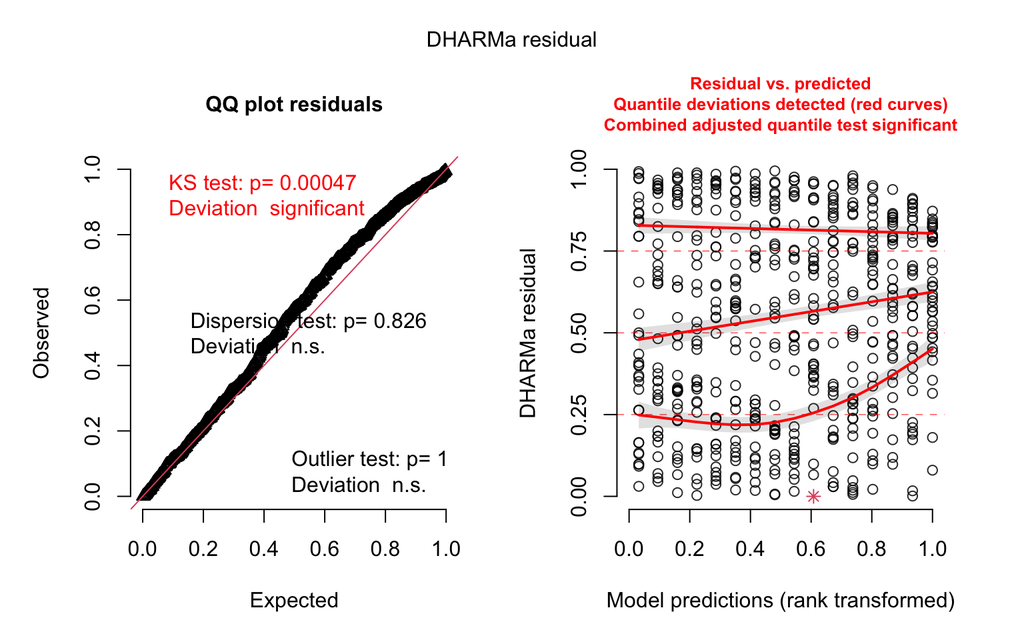

```r
# Plot Q-Q and Residuals vs Fitted plots

plot(simulationOutput)
```

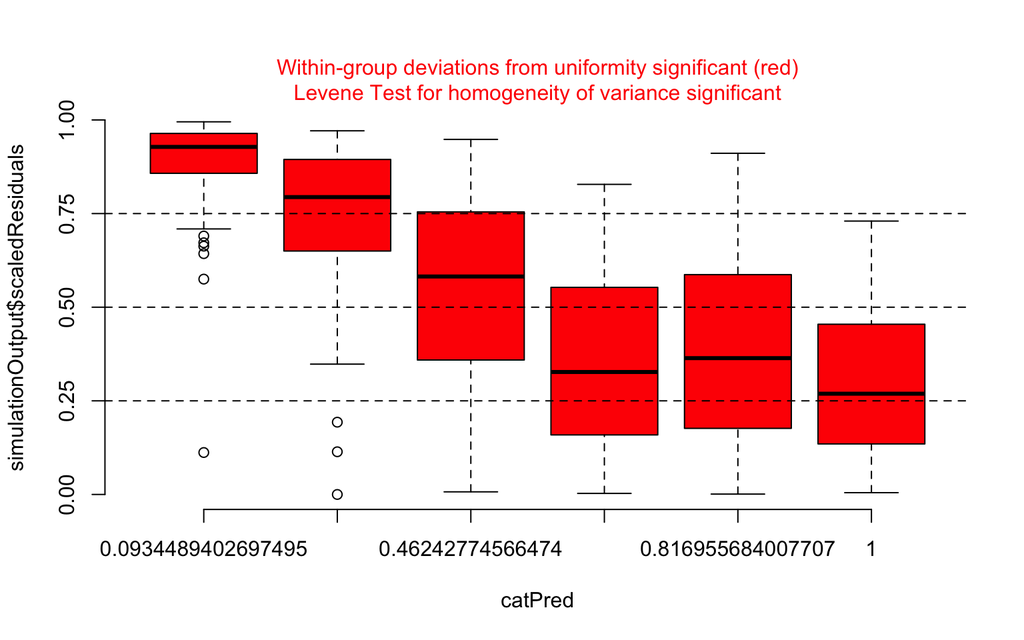

```r
# Plot residuals against specific predictors to check if residuals are
# independent of these variables

plotResiduals(simulationOutput,
              form = data_for_analysis$day)
```

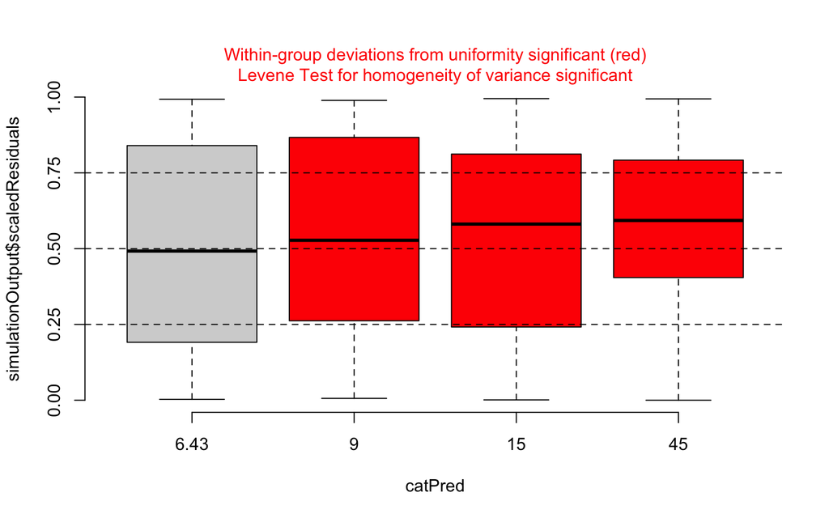

```r
plotResiduals(simulationOutput,
              form = data_for_analysis$size)
```

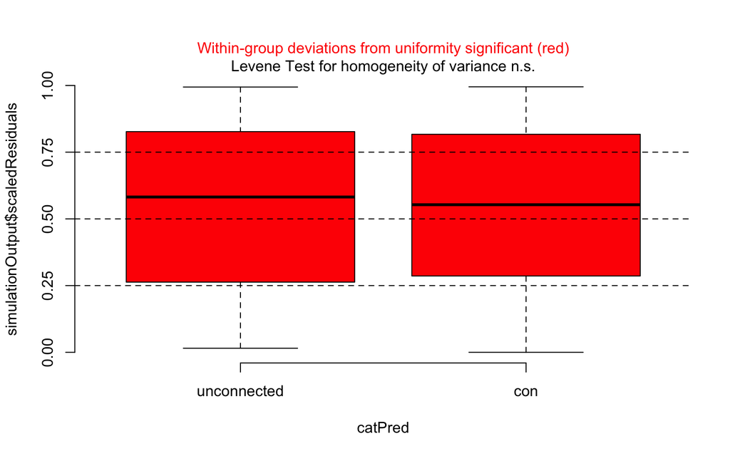

```r
plotResiduals(simulationOutput,
              form = data_for_analysis$conn)
```

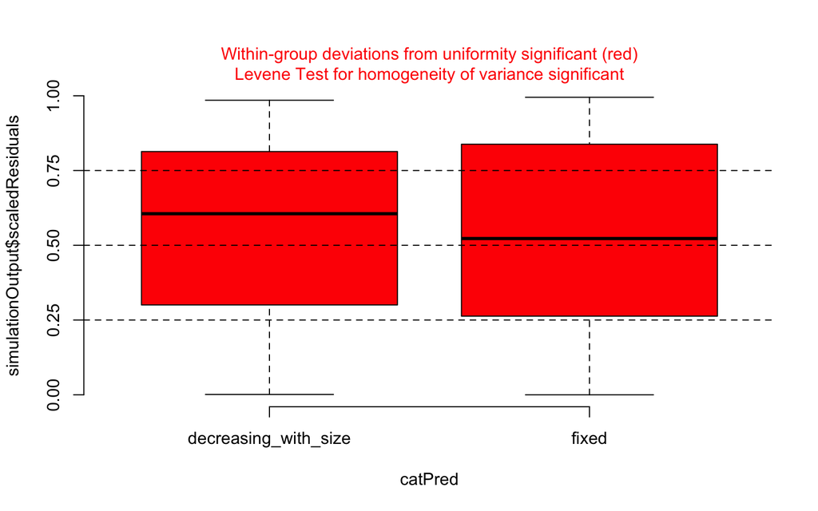

```r
plotResiduals(simulationOutput,
              form = data_for_analysis$dis_per)
```

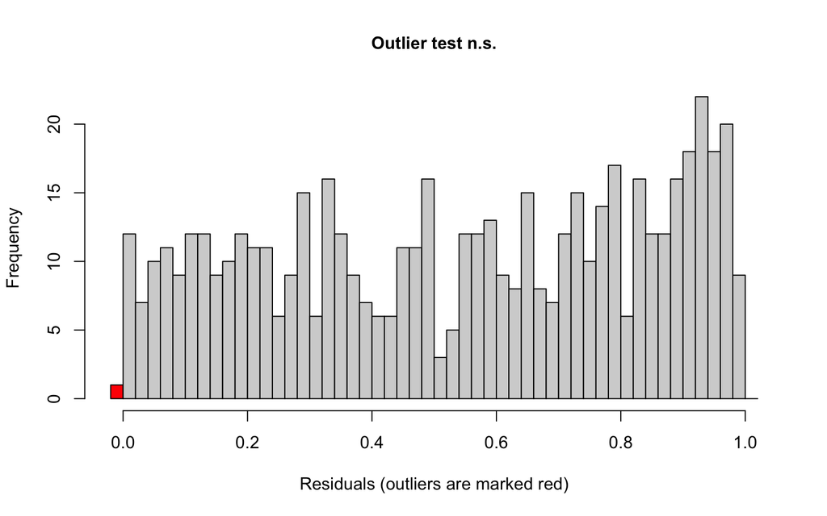

```
##
##  DHARMa outlier test based on exact binomial test with approximate
##  expectations
##
## data:  simulationOutput
## outliers at both margin(s) = 1, observations = 566, p-value = 1
## alternative hypothesis: true probability of success is not equal to 0.001998002
## 95 percent confidence interval:
##  4.473011e-05 9.804230e-03
## sample estimates:
## frequency of outliers (expected: 0.001998001998002 )
##                                          0.001766784
```

```r
# Test for outliers

testOutliers(simulationOutput)
```

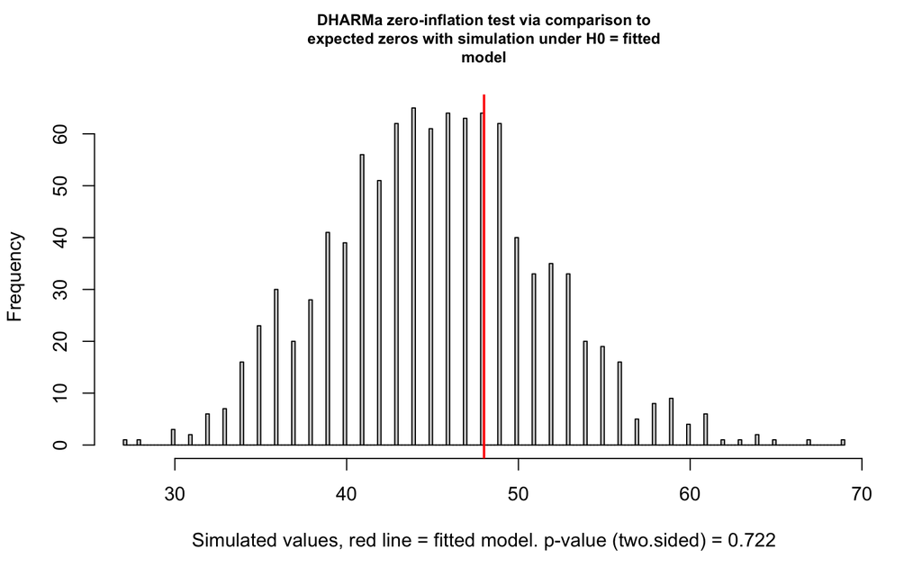

```
##
##  DHARMa zero-inflation test via comparison to expected zeros with
##  simulation under H0 = fitted model
##
## data:  simulationOutput
## ratioObsSim = 1.0582, p-value = 0.722
## alternative hypothesis: two.sided
```

```r
# Test for zero inflation not accounted for

testZeroInflation(simulationOutput)
```

### BEF

```r
# --- PREPARE DATA FOR PLOTTING --- #

data_for_plotting = ds_ecosystems %>%
  filter(trophic_type == "heterotrophic",
         species_richness != 0)
```

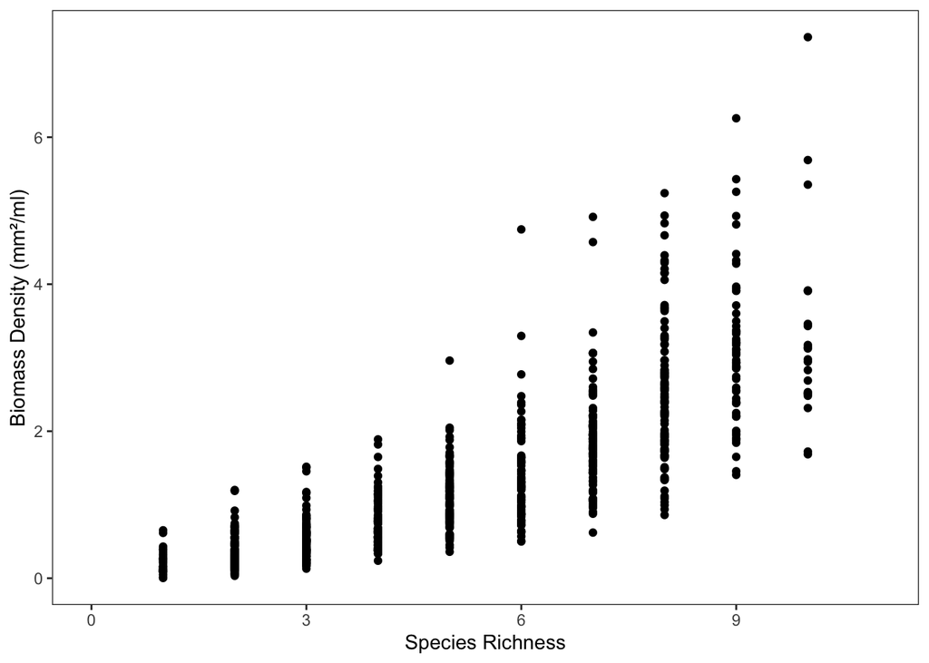

```r
# --- PLOT ECOSYSTEM BIOMASS VS SPECIES RICHNESS --- #

data_for_plotting %>%
  ggplot(aes(x = species_richness,
             y = bioarea_mm2_per_ml)) +
  geom_point() +
  xlim(0, length(protist_species)) +
  labs(x = axis_names$axis_name[axis_names$variable == "species_richness"],
       y = axis_names$axis_name[axis_names$variable == "bioarea_mm2_per_ml"]) +
  theme_bw() +
    theme(panel.grid.major = element_blank(),
          panel.grid.minor = element_blank(),
          legend.position = legend_position,
          legend.key.width = unit(legend_width_cm, "cm"))
```

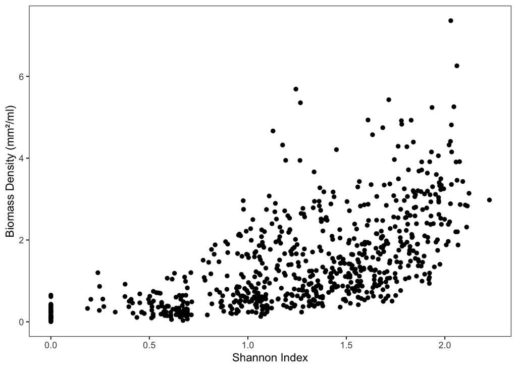

```r
# --- PLOT ECOSYSTEM BIOMASS VS SHANNON INDEX --- #

data_for_plotting %>%
  ggplot(aes(x = shannon,
             y = bioarea_mm2_per_ml)) +
  geom_point() +
  labs(x = axis_names$axis_name[axis_names$variable == "shannon"],
       y = axis_names$axis_name[axis_names$variable == "bioarea_mm2_per_ml"]) +
  theme_bw() +
    theme(panel.grid.major = element_blank(),
          panel.grid.minor = element_blank(),
          legend.position = legend_position,
          legend.key.width = unit(legend_width_cm, "cm"))
```

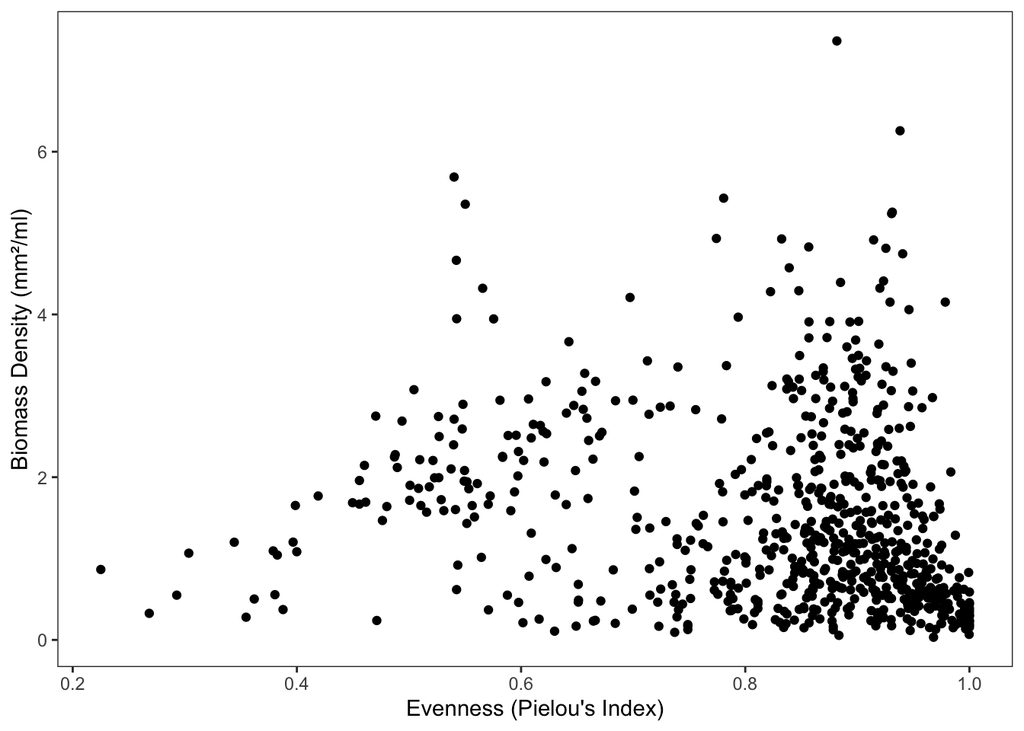

```r
# --- PLOT ECOSYSTEM BIOMASS VS EVENNESS --- #

data_for_plotting %>%
  filter(!is.na(evenness_pielou)) %>%
  ggplot(aes(x = evenness_pielou,
             y = bioarea_mm2_per_ml)) +
  geom_point() +
  labs(x = axis_names$axis_name[axis_names$variable == "evenness_pielou"],
       y = axis_names$axis_name[axis_names$variable == "bioarea_mm2_per_ml"]) +
  theme_bw() +
    theme(panel.grid.major = element_blank(),
          panel.grid.minor = element_blank(),
          legend.position = legend_position,
          legend.key.width = unit(legend_width_cm, "cm"))
```

## Other

### Running time

```r
end_time = Sys.time()
round(end_time - start_time, digits = 1)
```

```
## Time difference of 1.6 mins
```

### Useful code

If you want to change a certain part of the code using the following code in Unix:

```r
#Rmd script
cd /Users/ema/Documents/GitHub/RelativeSize/r_files
sed -i '' 's/old_string/new_string/g' *.Rmd

#R script
cd /Users/ema/Documents/GitHub/RelativeSize/r_files/functions
sed -i '' 's/old_string/new_string/g' *.R
```

If you want to share a dataset and get a reproducible object, use the following R code:

```r
dput()
```

If you want to create a hidden section:

```r
<details>
<summary>Click here to .../summary>
</details>
```

Save files to calculate the effect size of meta-ecosystems.

```r
write.csv(combination_sets_isolated_systems,
          file = here("files_for_ds_metaecos_es", "combination_sets_isolated_systems.csv"))

write.csv(ds_metaecosystems,
          file = here("files_for_ds_metaecos_es", "ds_metaecosystems.csv"))

write.csv(ds_metaecosystems,
          file = here("files_for_ds_metaecos_es", "ds_metaecosystems.csv"))
```

## Bibliography

Borenstein, Michael, Larry V. Hedges, Julian P. T. Higgins, and Hannah Rothstein. 2009. *Introduction to Meta-Analysis*. John Wiley & Sons.

Hedges, Larry V., and Ingram Olkin. 1985. *Statistical Methods for Meta-Analysis*. Elsevier. https://doi.org/10.1016/C2009-0-03396-0.

Rosenberg, Michael S., Hannah R. Rothstein, and Jessica Gurevitch. 2013. “Effect Sizes: Conventional Choices and Calculations.” In *Handbook of Meta-Analysis in Ecology and Evolution*, 61–71. https://doi.org/10.23943/princeton/9780691137285.003.0006.